# DESCRIPTIVA, INFERENCIA Y REGRESIONES SIMPLES

Lluis Albareda Dauder

23/3/2021

DESCARGA DE LIBRERIAS

```r
library(ggplot2)
library(dplyr)
library(e1071)
library(readxl)
library(stats)
library(modeest)
library(janitor)
library(ggcorrplot)
library(GGally)
library(lmtest)
library(car)
library(gvlma)
library(performance)
library(bestNormalize)
```

LECTURA DE DATOS

```r
Tabla <- read_excel("C:/Users/Usuario/Desktop/BIG DATA & ANALYTICS/MASTER/2- ESTADISTICA Y ANALISIS DE DATOS/Tablas/01.- Práctica Análisis Estadístico de Datos (Tabla).xlsx")
```

1- Desarrollar un analisis descriptivo siguiendo los siguientes pasos:

```r
str(Tabla)
```

```
## tibble [4,403 x 18] (S3: tbl_df/tbl/data.frame)
##  $ REGISTRO           : num [1:4403] 1 2 3 4 5 6 7 8 9 10 ...
##  $ PROVINCIA          : chr [1:4403] "Albacete" "Albacete" "Albacete" "Albacete" ...
##  $ rentabieco         : num [1:4403] 0.86 -4.748 -0.322 12.99 1.461 ...
##  $ rentabifin         : num [1:4403] 8.4 -20.15 -1.93 28.38 55.74 ...
##  $ endp               : num [1:4403] 89.8 76.4 83.3 54.2 97.4 ...
##  $ liq                : num [1:4403] 1.102 1.308 0.854 1.577 1.009 ...
##  $ PRODUCTIVIDAD      : num [1:4403] 114.9 146.4 11.7 19.3 37 ...
##  $ VENTAS             : num [1:4403] 1270 338 17715 20848 1239 ...
##  $ NÚMERO DE EMPLEADOS: num [1:4403] 1 1 46 40 2 54 1 2 8 2 ...
##  $ coe                : num [1:4403] 0.00493 0.00131 0.06871 0.08086 0.0048 ...
##  $ edad               : num [1:4403] 2 8 25 24 2 40 10 11 10 15 ...
##  $ conce              : num [1:4403] 9 9 34 34 3 34 34 34 9 34 ...
##  $ numac              : num [1:4403] 1 0 3 3 0 1 1 1 3 0 ...
##  $ numpa              : num [1:4403] 0 0 0 0 0 0 0 0 0 0 ...
##  $ numest             : num [1:4403] 1 1 2 2 2 7 1 1 1 2 ...
##  $ estp               : num [1:4403] 0 0 0 0 0 1 0 0 0 0 ...
##  $ grupo              : num [1:4403] 0 0 0 0 0 0 0 0 0 0 ...
##  $ fju                : num [1:4403] 0 0 1 1 0 1 0 0 1 1 ...
```

La Tabla tiene un total de 4.403 filas y 18 columnas. De las 18 columnas, 17 estan representados por valores numericos y 1 por caracter.

1.1-

VENTAS

Para medir la posicion, dispersion y forma que tiene nuestra variable “Ventas” usaremos los siguientes estadadisticos descriptivos:

-Medidas de posicion

Media:

```r
mean(Tabla$VENTAS)
```

```
## [1] 6648.156
```

Minimo, primer cuartil, mediana, tercer cuartil y maximo:

```r
fivenum(Tabla$VENTAS)
```

```
## [1]     4.924   494.886  1592.143  7819.906 77055.789
```

Valor/es de moda:

```r
mfv(Tabla$VENTAS)
```

```
## [1]  30.000 417.610 477.933 551.725
```

Puntos a destacar:

La media es aproximadamente 4 veces mayor a la mediana, es decir, hay mucha diferencia entre la mayoria de valores y los valores mas altos, haciendo que la media de las ventas suba mucho.

La media esta mucho mas cerca al tercer cuartil que a la mediana, esto denota que la mayoria de valores estan agrupados dentro de un rango de ventas no muy elevado, pero que los outliers ( valores mas grandes de la variable) influyen a subir mucho la media total.

Mucha diferencia entre minimo y maximo, en este caso la mayoria de valores estan mas cerca del minimo que del maximo.

Los valores de moda estan cercal del primer cuartil y por debajo de la mediana, confirmando lo anteriormente comentado, muchos valores acumulados en ventas pequeñas.

Boxplot stats:

```r
boxplot.stats(Tabla$VENTAS)
```

```
## $stats
## [1]     4.924   494.886  1592.143  7819.906 18785.613
##
## $n
## [1] 4403
##
## $conf
## [1] 1417.725 1766.561
##
## $out
##   [1] 20847.93 20070.99 38452.52 25096.90 28046.55 34044.16 35036.96 23324.61
##   [9] 24328.21 40997.66 28849.72 55761.01 49046.09 66262.16 31029.61 53202.14
##  [17] 24638.58 33575.43 20982.24 39586.16 36758.30 34998.20 31685.51 23644.70
##  [25] 19547.13 37617.67 22402.88 28019.49 50322.92 24146.56 25195.35 21689.09
##  [33] 47273.26 60807.73 50610.27 46125.95 29409.76 28947.23 23036.69 20041.44
```

[output cut: 53 more lines]

Con los stats sacados de la formula boxplot.stats podemos dibujar el diagrama de caja y bigotes. La diferencia de estos stats con los valores sacados de fivenum, es que en stats, hemos modificado el maximo por el bigote superior, dejando a su derecha un total de 458 outliers.

Diagrama de caja y bigotes:

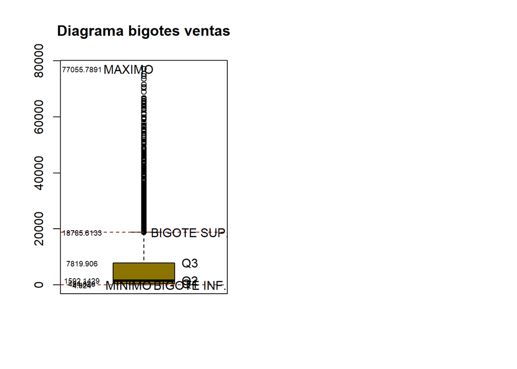

```r
boxplot2<-function(x,y)
{
  stats=boxplot.stats(x)$stats
  f=fivenum(x)
  stats2<-c(f[1],stats,f[5])
  stats3<-c(f[1],f[5])

  boxplot(x,main=y,col="gold4")
  abline(h=stats[1],lty=2,col="firebrick4")
  abline(h=stats[5],lty=2,col="firebrick4")
  text(rep(1.3,5),stats,labels=c('BIGOTE INF.','Q1','Q2','Q3','BIGOTE SUP.'))
  text(rep(0.6,7),stats2,labels=round(stats2,digits=4),cex=0.6)
  text(rep(0.9,2),stats3,labels=c('MINIMO','MAXIMO'))
}
par(mfrow=c(1,2))
boxplot2(Tabla$VENTAS, 'Diagrama bigotes ventas')
```

En el diagrama de bigotes, podemos ver dibujado los stats de las ventas. Apreciamos la cercania que hay entre el bigote inferior, Q1 y Q2 (Mediana). El 50% de las empresas tiene entre 4.924 - 1592.143, el siguiente 25% tiene entre 1592.143 y 7819.90.

El primer 50% de las ventas, esta muy agrupado en valores bajos, el siguiente 25% de valores estan un poco mas separados, es decir, tienen un rango de ventas mas amplio y los valores de ventas estan mas dispersos.

El ultimo 25 % de las ventas, las superiores al Q3, estan en un rango enorme de ventas, mucho mas dispersas que en los tramos anteriores.

-Medidas de dispersion:

Varianza

Desviacion Tipica

Coeficiente variacion de Pearson

Coeficiente de asimetria fisher

```r
var(Tabla$VENTAS)
```

```
## [1] 124930967
```

```r
sd(Tabla$VENTAS)
```

```
## [1] 11177.25
```

```r
sd(Tabla$VENTAS)/mean(Tabla$VENTAS)
```

```
## [1] 1.681256
```

```r
skewness(Tabla$VENTAS)
```

```
## [1] 2.814779
```

El coeficiente de variacion es = 1.68, nos indica que la media no tiene representacion.

El coeficiente de asimetria de Fisher es = 2.81, indica que existe una asimetria positiva porque los valores estan acumulados por debajo de la media, tal y como podemos ver en el siguiente histograma de ventas:

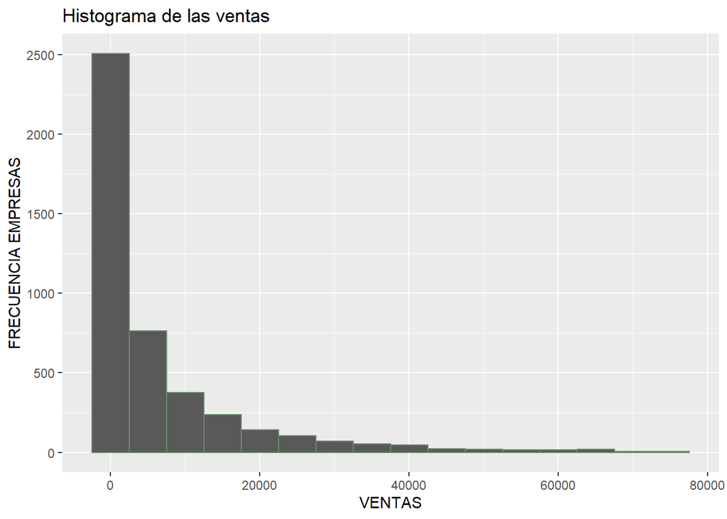

```r
Histograma<-ggplot(data=Tabla, aes(x=VENTAS))+
  geom_histogram(binwidth=5000, color="darkseagreen4", aes(fill=REGISTRO))+
  xlab("VENTAS")+
  ylab("FRECUENCIA EMPRESAS")+
  theme(legend.position="top")+
  #theme(legend.position="none")+
  ggtitle("Histograma de las ventas")

Histograma
```

-Medidas de forma

Coeficiente de Curtosis

```r
kurtosis(Tabla$VENTAS)
```

```
## [1] 9.104839
```

Segun el coeficiente de Curtosis, las ventas estan dividadas de forma Leptocurtica, es decir, las ventas estan apuntadas en forma de pico en los valores de moda, el pico va reduciendo altura una vez pasada la mediana y finalmente con colas muy poco anchas una vez superada la media.

El siguiente grafico de dispersion, nos enseña de una forma visual como los valores cada vez estan mas dispersos a medida que las ventas crecen.

Grafico de dispersion

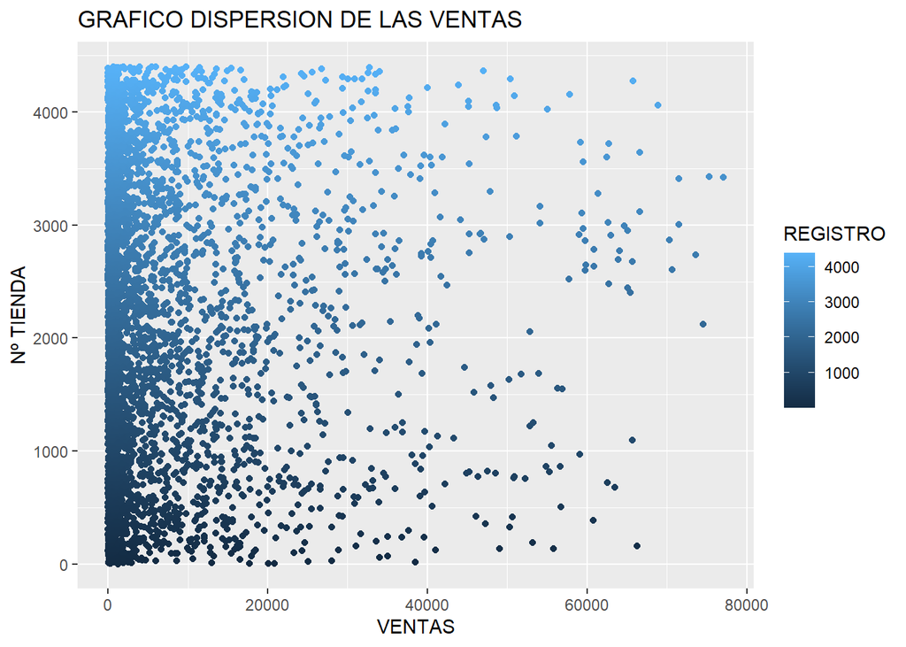

```r
grafico<-ggplot(data=Tabla, aes(x=VENTAS, y=REGISTRO))
grafico+geom_point(aes(color=REGISTRO))+xlab("VENTAS")+ylab("Nº TIENDA")+ggtitle("GRAFICO DISPERSION DE LAS VENTAS")
```

NUMERO DE EMPLEADOS

Realizaremos los mismos analisis de posicion, dispersion y forma para la columna NUMERO DE EMPLEADOS de nuestro data frame.

-Medidas de posicion

Media:

```r
mean(Tabla$`NÚMERO DE EMPLEADOS`)
```

```
## [1] 16.33591
```

Minimo, primer cuartil, mediana, tercer cuartil y maximo:

```r
fivenum(Tabla$`NÚMERO DE EMPLEADOS`)
```

```
## [1]   1   3   7  21 169
```

Valor/es de moda:

```r
mfv(Tabla$`NÚMERO DE EMPLEADOS`)
```

```
## [1] 1
```

Puntos a destacar:

El valor de moda del numero de empleados es igual al minimo de empleados, es decir, la frecuencia mas grande de empleados en las empresas de la tabla es 1.

El 75% de las empresas se encuentran en el rando de [1,21] empleados, el 25% restante entre empresas con mas de 21 empleados hasta 169 empleados.

Mucha acumulacion de empresas con pocos empleados y mucha dispersion de empresas a medida que hay mas empleados.

Mucha diferencia entre minimo y maximo, en este caso la mayoria de valores estan mas cerca del minimo que del maximo.

Boxplot stats:

```r
boxplot.stats(Tabla$`NÚMERO DE EMPLEADOS`)
```

```
## $stats
## [1]  1  3  7 21 48
##
## $n
## [1] 4403
##
## $conf
## [1] 6.571397 7.428603
##
## $out
##   [1]  54 123  58  49  86  57  56  50 108  50 108 114  62  75  62  51  63  60
##  [19]  74  50  51  55  61  65  83  97  52  70  57  81 115 146 122  74  61  55
##  [37]  51  49  67  60  74  89  80  81  88  67  63  49  56  60  58  54  58  68
##  [55] 133  72  67  50  73 120  89 109  78 103  66 123  63  84  67  90  49  82
##  [73]  56  78  88  69  64  69  53  54 106  56  91 156  61  52  84  66  54  63
```

[output cut: 16 more lines]

Con los stats sacados con la formula boxplot.stats podemos dibujar el diagrama de caja y bigotes. La diferencia de estos stats con los valores sacados de fivenum, es que en stats, hemos modificado el maximo por el bigote superior, dejando a su derecha un total de 364 outliers.

Diagrama de caja y bigotes:

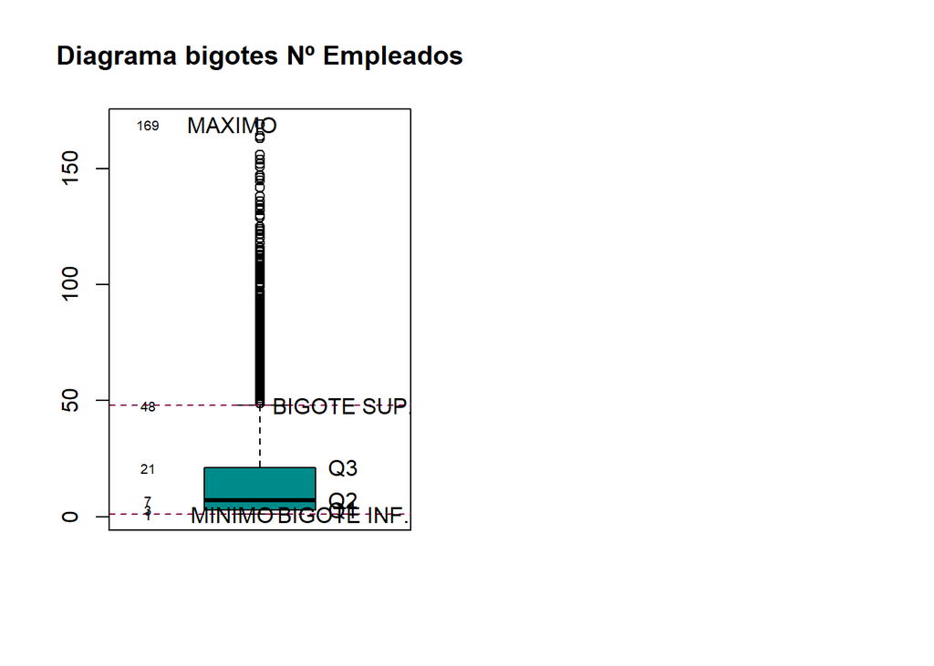

```r
boxplot2<-function(x,y)
{
  stats=boxplot.stats(x)$stats
  f=fivenum(x)
  stats2<-c(f[1],stats,f[5])
  stats3<-c(f[1],f[5])

  boxplot(x,main=y,col="darkcyan")
  abline(h=stats[1],lty=2,col="deeppink4")
  abline(h=stats[5],lty=2,col="deeppink4")
  text(rep(1.3,5),stats,labels=c('BIGOTE INF.','Q1','Q2','Q3','BIGOTE SUP.'))
  text(rep(0.6,7),stats2,labels=round(stats2,digits=4),cex=0.6)
  text(rep(0.9,2),stats3,labels=c('MINIMO','MAXIMO'))
}
par(mfrow=c(1,2))
boxplot2(Tabla$`NÚMERO DE EMPLEADOS`, 'Diagrama bigotes Nº Empleados')
```

En el diagrama de bigotes, podemos ver dibujado los stats de los empleados. Apreciamos la cercania que hay entre el bigote inferior, Q1 y Q2 (Mediana). El 50 % de las empresas tiene entre 1 y 7 empleados.

El primer 50% de los empleados esta acumulado en empresas de 1 a 7 trabajadores, el siguiente 25% de las empresas esta mas disperso en un rango de 7 a 21 empleados, finalmente el 25% restante de las empresas estan dispersas en un rango de empleados mucho mayor.

-Medidas de dispersion:

Varianza

Desviacion Tipica

Coeficiente variacion de Pearson

Coeficiente de asimetria fisher

```r
var(Tabla$`NÚMERO DE EMPLEADOS`)
```

```
## [1] 507.8447
```

```r
sd(Tabla$`NÚMERO DE EMPLEADOS`)
```

```
## [1] 22.53541
```

```r
sd(Tabla$`NÚMERO DE EMPLEADOS`)/mean(Tabla$`NÚMERO DE EMPLEADOS`)
```

```
## [1] 1.379502
```

```r
skewness(Tabla$`NÚMERO DE EMPLEADOS`)
```

```
## [1] 2.602471
```

El coeficiente de variacion es = 1.38, nos indica que la media no tiene representacion.

El coeficiente de asimetria de Fisher es = 2.60, indica que existe una asimetria positiva porque los valores estan acumulados por debajo de la media, tal y cOmo podemos ver en el siguiente histograma de empleados:

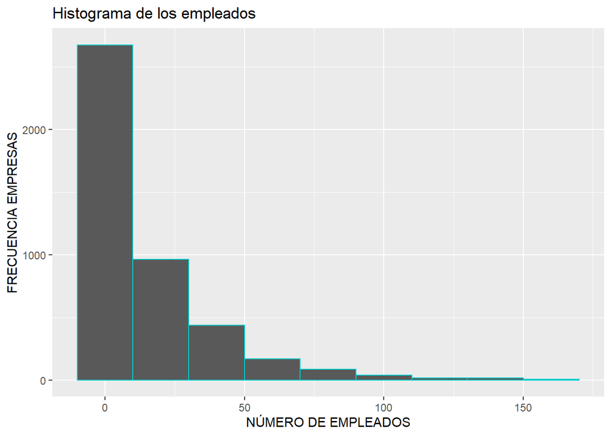

```r
Histograma<-ggplot(data=Tabla, aes(x=`NÚMERO DE EMPLEADOS`))+
  geom_histogram(binwidth=20, color="cyan3", aes(fill=REGISTRO))+
  xlab("NÚMERO DE EMPLEADOS")+
  ylab("FRECUENCIA EMPRESAS")+
  theme(legend.position="top")+
  #theme(legend.position="none")+
  ggtitle("Histograma de los empleados")

Histograma
```

-Medidas de forma

Coeficiente de Curtosis

```r
kurtosis(Tabla$`NÚMERO DE EMPLEADOS`)
```

```
## [1] 8.527611
```

Segun el coeficiente de Curtosis, los empleados estan divididos de forma Leptocurtica, es decir, en el valor de moda ( numero de empleados = 1 ) empieza con un gran volumen de empresas, realizando una forma de pico, a medida que los empleados van crecienco, cada vez hay menos empresas acumuladas, realizando bruscamente un descenso una vez superada la media de los empleados que acaba terminando en colas muy estechas.

El siguiente grafico de dispersion, nos enseñaa de una forma visual como estan acumuladas las empresas, segun el numero de empleados y como a medida que los empleados crecen, la dispersion de las empresas aumenta notoriamente.

GrAfico de dispersion

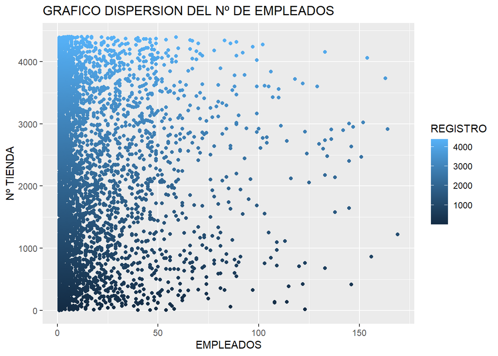

```r
grafico<-ggplot(data=Tabla, aes(x=`NÚMERO DE EMPLEADOS`, y=REGISTRO))
grafico+geom_point(aes(color=REGISTRO))+xlab("EMPLEADOS")+ylab("Nº TIENDA")+ggtitle("GRAFICO DISPERSION DEL Nº DE EMPLEADOS")
```

PRODUCTIVIDAD

Realizaremos los mismos analisis de posicion, dispersion y forma para la columna PRODUCTIVIDAD de nuestro data frame.

-Medidas de posicion

Media:

```r
mean(Tabla$PRODUCTIVIDAD)
```

```
## [1] 16.22448
```

Minimo, primer cuartil, mediana, tercer cuartil y maximo:

```r
fivenum(Tabla$PRODUCTIVIDAD)
```

```
## [1]  -1.171737   5.084923  11.755181  18.783176 268.593079
```

Valor/es de moda:

```r
mfv(Tabla$PRODUCTIVIDAD)
```

```
## [1]  1.506865 13.359476
```

Puntos a destacar:

Los valores de moda de la productividad se encuentran en un rango de productividad baja, pero a diferencia del resto de variables, en este caso vemos que los valores de moda se encuentran en aprox. el 50% mas pequeño de la productividad, es decir, muchas empresas en un rango de productividad pequeño.

La media se encuentra entre el Q2 y el Q3, por lo que todos los valores superiores al Q3, es decir, el 25% restante de la productividad, influye en que la media suba pero en este caso la influencia no es muy grande.

El 75% de las empresas se encuentran en el rando de [-1,17,18,78] productividad, el 25% restante entre empresas con una productividad superior a 18.78 hasta 268.59.

Mucha acumulacion de empresas con una productividad inferior a 18,78.

Mucha diferencia entre minimo y maximo, en este caso la gran mayoria de valores estan mucho mas cerca del minimo que del maximo.

Boxplot stats:

```r
boxplot.stats(Tabla$PRODUCTIVIDAD)
```

```
## $stats
## [1] -1.171737  5.084923 11.755181 18.783176 39.196732
##
## $n
## [1] 4403
##
## $conf
## [1] 11.42901 12.08135
##
## $out
##   [1] 114.91889 146.38667  70.81925  44.78419  53.98889  44.82796  39.87148
##   [8]  46.50921  43.85441  71.88331 157.82806  49.49941  44.05070  65.28147
##  [15]  57.33990 143.96021  47.03058  41.05291  59.11451 114.95753  49.64670
##  [22]  47.36809  78.67809  41.89939  41.68603  90.95718  64.94444  44.95728
##  [29]  70.73589  40.67828  54.18986  74.61082 200.08482  88.80454  42.63382
```

[output cut: 41 more lines]

Con los stats sacados con la formula boxplot.stats podemos dibujar el diagrama de caja y bigotes. La diferencia de estos stats con los valores sacados de fivenum, es que en stats, hemos modificado el maximo por el bigote superior, dejando a su derecha un total de 320 outliers.

Diagrama de caja y bigotes:

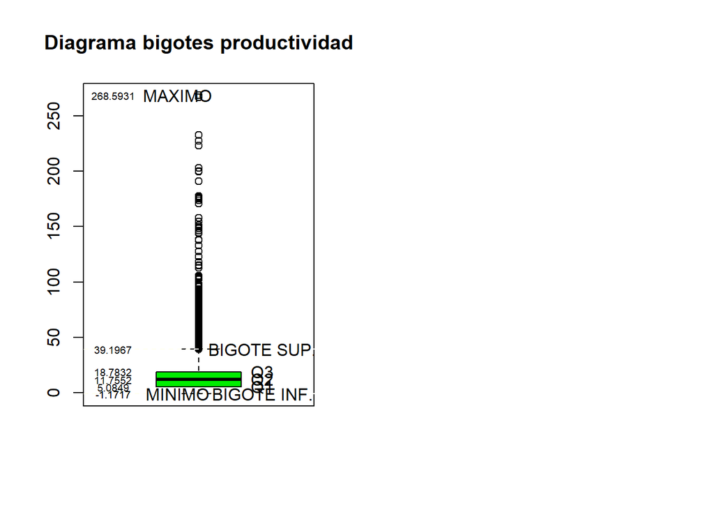

```r
boxplot2<-function(x,y)
{
  stats=boxplot.stats(x)$stats
  f=fivenum(x)
  stats2<-c(f[1],stats,f[5])
  stats3<-c(f[1],f[5])

  boxplot(x,main=y,col="green2")
  abline(h=stats[1],lty=2,col="ivory")
  abline(h=stats[5],lty=2,col="ivory")
  text(rep(1.3,5),stats,labels=c('BIGOTE INF.','Q1','Q2','Q3','BIGOTE SUP.'))
  text(rep(0.6,7),stats2,labels=round(stats2,digits=4),cex=0.6)
  text(rep(0.9,2),stats3,labels=c('MINIMO','MAXIMO'))
}
par(mfrow=c(1,2))
boxplot2(Tabla$PRODUCTIVIDAD, 'Diagrama bigotes productividad')
```

En el diagrama de bigotes, podemos ver dibujado los stats de la productividad. Apreciamos la cercania que hay entre el bigote inferior, Q1, Q2 (Mediana) y el Q3.

El 75 % de las empresas, tiene un productividad muy parecida. A diferencia del resto de variables, la productividad acumula el 75 % de las empresas en un rango muy pequeño, el siguiente 25 % de las empresas estan muy dispersas en un rango aproximadamente 12 veces mayor.

-Medidas de dispersion:

Varianza

Desviacion Tipica

Coeficiente variacion de Pearson

Coeficiente de asimetria fisher

```r
var(Tabla$PRODUCTIVIDAD)
```

```
## [1] 407.9152
```

```r
sd(Tabla$PRODUCTIVIDAD)
```

```
## [1] 20.19691
```

```r
sd(Tabla$PRODUCTIVIDAD)/mean(Tabla$PRODUCTIVIDAD)
```

```
## [1] 1.244842
```

```r
skewness(Tabla$PRODUCTIVIDAD)
```

```
## [1] 4.890364
```

El coeficiente de variacion es = 1.24, nos indica que la media no tiene representacion.

El coeficiente de asimetria de Fisher es = 4.89, indica que existe una asimetria positiva porque los valores estan acumulados por debajo de la media, tal y como podemos ver en el siguiente histograma de productividad:

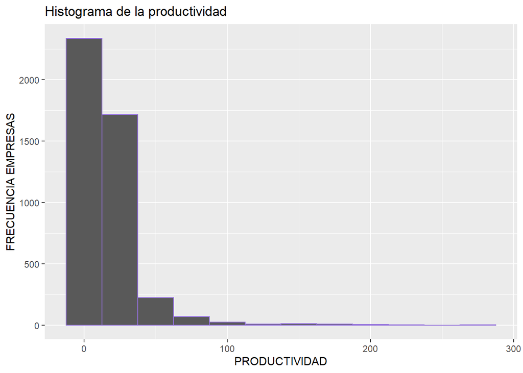

```r
Histograma<-ggplot(data=Tabla, aes(x=PRODUCTIVIDAD))+
  geom_histogram(binwidth=25, color="mediumpurple", aes(fill=REGISTRO))+
  xlab("PRODUCTIVIDAD")+
  ylab("FRECUENCIA EMPRESAS")+
  theme(legend.position="top")+
  #theme(legend.position="none")+
  ggtitle("Histograma de la productividad")

Histograma
```

-Medidas de forma

Coeficiente de Curtosis

```r
kurtosis(Tabla$PRODUCTIVIDAD)
```

```
## [1] 36.93594
```

Segun el coeficiente de Curtosis, la productividad esta dividada de forma Leptocurtica, es decir, la productividad esta apuntada entre el primer 75%, una vez superado el Q3 existe un gran descenso terminando en colas muy poco anchas.

El siguiente grafico de dispersion, nos enseña de una forma visual como en este caso la acumulacion de empresas es mas ancho que con el resto de variable, una vez superada la productividad de 18.78 las empresas se dispersan muchisimo mas.

Grafico de dispersiÃ³n

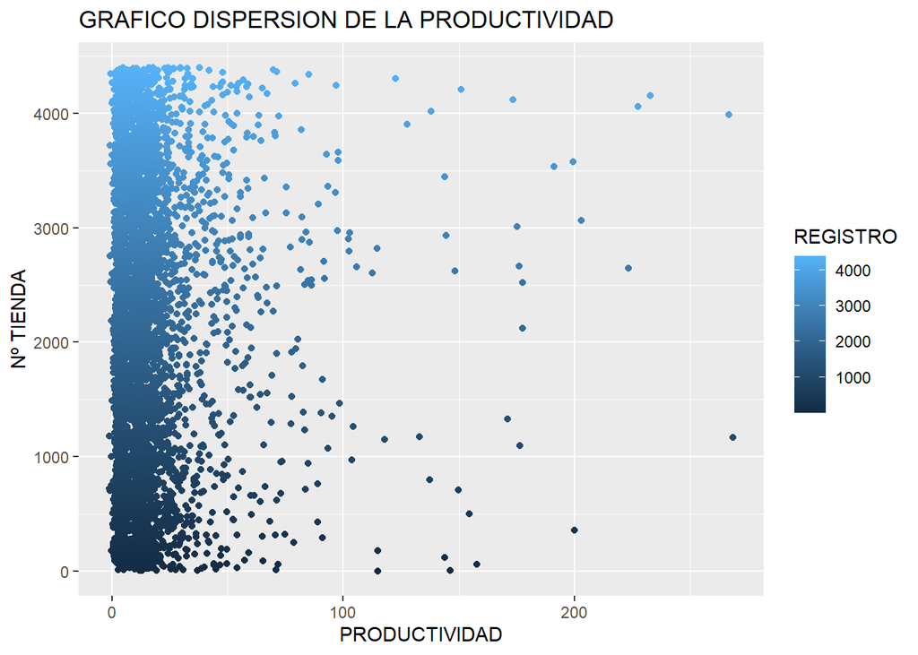

```r
grafico<-ggplot(data=Tabla, aes(x=PRODUCTIVIDAD, y=REGISTRO))
grafico+geom_point(aes(color=REGISTRO))+xlab("PRODUCTIVIDAD")+ylab("Nº TIENDA")+ggtitle("GRAFICO DISPERSION DE LA PRODUCTIVIDAD")
```

Nuestras 3 variables se comportan de forma muy similar segun los estadisticos de posicion, dispersion y forma anteriormente usados.

Las variables Ventas y Empleados son los que tienen coeficiente de variacion, asimetria y de Curtosis mas parecido entre si.

La variable productividad, tiene caracteristicas muy similares, pero es cierto que tiene muchos valores acumulados por debajo de la media, pero en este caso, la forma de esta variable es mucho mas Lepltocurtica que las demas acumulando el 75 % de las empresas en la parte mas alta de la curva. Es importante considerar, que el Q1, Q2 Y Q3 estan muy juntos, por lo que indica, que el pico es muy elevado entre estos 3 puntos, empezando a disminuir bruscamente una vez superado el Q3.

1.3-

Matriz de correlaciOn lineal entre todas las variables:

```r
Tabla_sin_provincia <- Tabla %>% select(-PROVINCIA)
matriz_correlacion <- cor(Tabla_sin_provincia)
matriz_correlacion
```

```
##                          REGISTRO   rentabieco   rentabifin        endp
## REGISTRO             1.0000000000 -0.002946184  0.015088689  0.02483128
## rentabieco          -0.0029461844  1.000000000 -0.069675343 -0.49914580
## rentabifin           0.0150886887 -0.069675343  1.000000000  0.10846386
## endp                 0.0248312776 -0.499145800  0.108463860  1.00000000
## liq                 -0.0126527781  0.041895238 -0.031200508 -0.16044264
## PRODUCTIVIDAD        0.0187749229  0.069796433  0.095176009  0.04015234
## VENTAS               0.0227552628  0.109997272 -0.049340285 -0.14276928
## NÚMERO DE EMPLEADOS  0.0129629322  0.097935829 -0.076607127 -0.17458248
## coe                  0.0587146401  0.092461932 -0.021181758 -0.12487867
## edad                -0.0100919478  0.117505726 -0.147373362 -0.29325173
## conce                0.0160624968 -0.060610202  0.002107435  0.05826127
## numac               -0.0063193363  0.099549100 -0.060156975 -0.18371747
## numpa                0.0525184155  0.037158555 -0.036869634 -0.10682955
## numest              -0.0152826715  0.065932001 -0.045403120 -0.08564187
## estp                -0.0178042613  0.015815606 -0.013161947 -0.02072366
## grupo               -0.0119370979  0.038832950 -0.044934750 -0.06296610
## fju                  0.0008312158  0.086591404 -0.083798360 -0.20868490
##                              liq PRODUCTIVIDAD      VENTAS NÚMERO DE EMPLEADOS
## REGISTRO            -0.012652778  0.0187749229  0.02275526          0.01296293
## rentabieco           0.041895238  0.0697964328  0.10999727          0.09793583
## rentabifin          -0.031200508  0.0951760094 -0.04934028         -0.07660713
## endp                -0.160442645  0.0401523385 -0.14276928         -0.17458248
## liq                  1.000000000 -0.0179426359 -0.05424106         -0.05747665
## PRODUCTIVIDAD       -0.017942636  1.0000000000  0.07919562         -0.08295600
## VENTAS              -0.054241065  0.0791956194  1.00000000          0.88930023
## NÚMERO DE EMPLEADOS -0.057476646 -0.0829559979  0.88930023          1.00000000
## coe                 -0.037399826  0.0489531540  0.52952942          0.49881043
## edad                 0.037569793 -0.1631046678  0.36499112          0.43166520
## conce                0.015607659  0.0476160348  0.11718560          0.09041243
## numac               -0.010415609 -0.0000403951  0.32024961          0.33626516
## numpa                0.019048078 -0.0131204035  0.27779159          0.28416487
## numest              -0.033383556 -0.0216048845  0.48658969          0.51757886
## estp                -0.009869730  0.0029920975  0.18323340          0.18488798
## grupo               -0.009046215 -0.0123629568  0.22661930          0.23291949
## fju                  0.014602641 -0.0489707843  0.41529464          0.44297679
##                             coe        edad        conce         numac
## REGISTRO             0.05871464 -0.01009195  0.016062497 -0.0063193363
## rentabieco           0.09246193  0.11750573 -0.060610202  0.0995490997
## rentabifin          -0.02118176 -0.14737336  0.002107435 -0.0601569751
```

[output cut: 35 more lines]

```
## rentabifin          -0.0837983599
## endp                -0.2086849037
## liq                  0.0146026410
## PRODUCTIVIDAD       -0.0489707843
## VENTAS               0.4152946359
## NÚMERO DE EMPLEADOS  0.4429767880
## coe                  0.3046084148
## edad                 0.4998003025
## conce                0.0683864528
## numac                0.3368718256
## numpa                0.1816103242
## numest               0.2227827309
## estp                 0.0853474544
## grupo                0.2119249115
## fju                  1.0000000000
```

Las variables con mas correlacion entre si son:

1- VENTAS / NUMERO DE EMPLEADOS = 0,89

2- COE / VENTAS = 0,53

3- NUMEST / NUMERO DE EMPLEADOS = 0,52

4- FJU / EDAD = 0,50

5- COE/ NUMERO DE EMPLEADOS = 0,50

6- ENDP / RENTABIECO = -0,50

7- NUMEST / VENTAS = 0,49

8- FJU / NUMERO DE EMPLEADOS = 0,44

9- EDAD / NUMERO DE EMPLEADOS = 0,43

10- FJU / VENTAS = 0,42

Las variables, ventas, Nº empleados, coe (Cuota de mercado por provincias), numest (Numero de establecimientos), fju (Forma juridica), edad de la empresa, endp (endeudamiento), rentabieco (Rentabilidad Economica) tienen una significativa correlacion con una o mas variables de nuestro data frame.

Las 10 correlaciones mas potentes de nuestra nueva matriz, tienen sentido, muchas de ellas tienen relacion con las variables numero de empleados y ventas. Estas variables, tienden a explicar lo grande o pequeña que es la empresa.

En el siguiente grafico, podemos ver una forma mas visual, las correlaciones mas fuertes entre las variables anteriormente mencionadas.

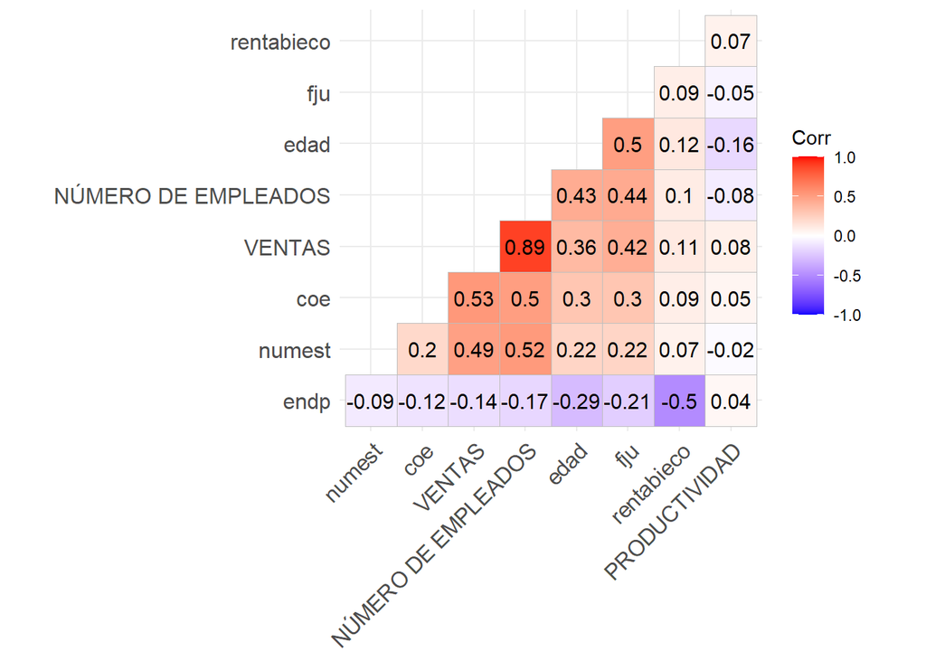

```r
ggcorrplot(cor(Tabla_sin_provincia[ , c(2, 4, 6, 7, 8, 9, 10, 14, 17)], use="complete.obs"), hc.order=TRUE, type="lower", lab=TRUE)
```

Para poder visualizar los datos de una forma mas eficaz, podemos crear una tabla de correlacion entre las variables con mayor correlacion, finalmente, si de esta nueva tabla, sacamos el R^2 vemos:

```r
Tabla_mayor_correlaciones <- Tabla %>% select(VENTAS, `NÚMERO DE EMPLEADOS`, rentabieco, endp, coe, numest, fju, edad )
(cor(Tabla_mayor_correlaciones))^2
```

```
##                         VENTAS NÚMERO DE EMPLEADOS  rentabieco        endp
## VENTAS              1.00000000         0.790854893 0.012099400 0.020383066
## NÚMERO DE EMPLEADOS 0.79085489         1.000000000 0.009591427 0.030479042
## rentabieco          0.01209940         0.009591427 1.000000000 0.249146529
## endp                0.02038307         0.030479042 0.249146529 1.000000000
## coe                 0.28040140         0.248811841 0.008549209 0.015594682
## numest              0.23676952         0.267887876 0.004347029 0.007334529
## fju                 0.17246963         0.196228435 0.007498071 0.043549389
## edad                0.13321852         0.186334847 0.013807596 0.085996575
##                             coe      numest         fju       edad
## VENTAS              0.280401404 0.236769524 0.172469635 0.13321852
## NÚMERO DE EMPLEADOS 0.248811841 0.267887876 0.196228435 0.18633485
## rentabieco          0.008549209 0.004347029 0.007498071 0.01380760
## endp                0.015594682 0.007334529 0.043549389 0.08599657
## coe                 1.000000000 0.039575237 0.092786286 0.08763764
## numest              0.039575237 1.000000000 0.049632145 0.04699761
## fju                 0.092786286 0.049632145 1.000000000 0.24980034
## edad                0.087637640 0.046997613 0.249800342 1.00000000
```

La correlacion entre VENTAS y NUMERO DE EMPLEADOS es muy fuerte, hay un R^2 del 0,79, del que podemos traducir, que un 79 % de la variabilidad de las ventas, esta explicado por la variabilidad del numero de empleados, o al inreves.

De todas las variables con una correlacion positiva o negativa alta, con diferencia, la variable que con mas porcentaje queda explicada por la otra, es VENTAS / EMPLEADOS. El resto de variables, vemos que tienen un R^2 entre un 17 y un 28 %.

Por ejemplo, la cuota de mercado por provincias, queda explicada en un 28% por variabilidad las ventas de la empresa.

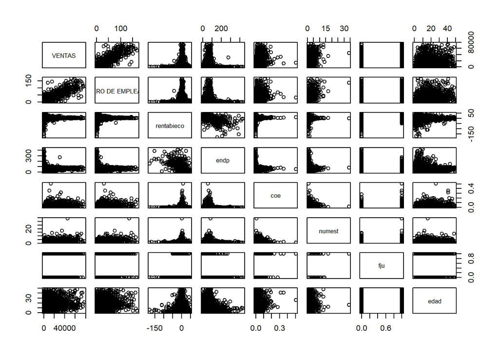

```r
pairs(Tabla_mayor_correlaciones)
```

En el grafico anterior, destacamos la relacion evidente entre Ventas y Numero de empleados, con el resto de variables, es mas complicado ver segun la matriz de diagrama de dispersion si existe una correlacion fuerte o no.

1.4-

INTERVALOS PARA LAS VENTAS

Para nuestro intervalo de las ventas, necesitamos conocer el valor maximo de ventas, el minimo y la longitud del intervalo, que en este caso sera de (maximo_valor - minimo_valor)/(Raiz de Cantidad de datos).

```r
MAX <- max(Tabla$VENTAS)
MAX
```

```
## [1] 77055.79
```

```r
MIN <- min(Tabla$VENTAS)
MIN
```

```
## [1] 4.924
```

```r
N <- (MAX-MIN)/(sqrt(4403))
N
```

```
## [1] 1161.19
```

```r
MAXN <- max(Tabla$VENTAS)+ N
MAXN
```

```
## [1] 78216.98
```

```r
MinMaxN=seq(MIN, MAXN, N)
```

Una vez encontrados estos datos, utilizamos la funcion CUT para crear nuestros intervalos.

```r
intervalos_ventas <-cut(Tabla$VENTAS, include.lowest = T, MinMaxN, labels=NULL, ordered_result = T, dig.lab = 5)
table(intervalos_ventas, useNA = "always")
```

```
## intervalos_ventas
##  [4.924,1166.1] (1166.1,2327.3] (2327.3,3488.5] (3488.5,4649.7] (4649.7,5810.9]
##            1924             532             272             204             160
## (5810.9,6972.1] (6972.1,8133.3] (8133.3,9294.4]  (9294.4,10456]   (10456,11617]
##             122             114             120              80              70
##   (11617,12778]   (12778,13939]   (13939,15100]   (15100,16262]   (16262,17423]
##              69              65              55              51              50
##   (17423,18584]   (18584,19745]   (19745,20906]   (20906,22068]   (22068,23229]
##              48              34              33              22              21
##   (23229,24390]   (24390,25551]   (25551,26712]   (26712,27873]   (27873,29035]
##              30              20              28              16              20
##   (29035,30196]   (30196,31357]   (31357,32518]   (32518,33679]   (33679,34841]
##              21              14              11              19              14
##   (34841,36002]   (36002,37163]   (37163,38324]   (38324,39485]   (39485,40647]
##              12               9               7              13              14
##   (40647,41808]   (41808,42969]   (42969,44130]   (44130,45291]   (45291,46453]
##               7               4               2               9               3
##   (46453,47614]   (47614,48775]   (48775,49936]   (49936,51097]   (51097,52258]
##               7               6               1               8               3
##   (52258,53420]   (53420,54581]   (54581,55742]   (55742,56903]   (56903,58064]
##               4               3               4               4               3
##   (58064,59226]   (59226,60387]   (60387,61548]   (61548,62709]   (62709,63870]
##               3               6               4               4               3
##   (63870,65032]   (65032,66193]   (66193,67354]   (67354,68515]   (68515,69676]
##               3               6               3               0               1
##   (69676,70837]   (70837,71999]   (71999,73160]   (73160,74321]   (74321,75482]
##               2               2               0               1               2
##   (75482,76643]   (76643,77805]            <NA>
##               0               1               0
```

Tenemos un total de 67 intervalos con una amplitud homogenea.

Introducimos los intervalos en nuestra tabla y verificamos que todos los valores han sido repartidos en una unica division:

```r
Tabla_INTERVALOS <- Tabla %>%  mutate(intervalos_ventas)
sum(table(Tabla_INTERVALOS$intervalos_ventas)) == nrow(Tabla_INTERVALOS)
```

```
## [1] TRUE
```

```r
prop.table(table(Tabla_INTERVALOS$intervalos_ventas))
```

```
##
##  [4.924,1166.1] (1166.1,2327.3] (2327.3,3488.5] (3488.5,4649.7] (4649.7,5810.9]
##    0.4369747899    0.1208267091    0.0617760618    0.0463320463    0.0363388599
## (5810.9,6972.1] (6972.1,8133.3] (8133.3,9294.4]  (9294.4,10456]   (10456,11617]
##    0.0277083806    0.0258914377    0.0272541449    0.0181694299    0.0158982512
##   (11617,12778]   (12778,13939]   (13939,15100]   (15100,16262]   (16262,17423]
##    0.0156711333    0.0147626618    0.0124914831    0.0115830116    0.0113558937
##   (17423,18584]   (18584,19745]   (19745,20906]   (20906,22068]   (22068,23229]
##    0.0109016580    0.0077220077    0.0074948898    0.0049965932    0.0047694754
##   (23229,24390]   (24390,25551]   (25551,26712]   (26712,27873]   (27873,29035]
##    0.0068135362    0.0045423575    0.0063593005    0.0036338860    0.0045423575
##   (29035,30196]   (30196,31357]   (31357,32518]   (32518,33679]   (33679,34841]
##    0.0047694754    0.0031796502    0.0024982966    0.0043152396    0.0031796502
##   (34841,36002]   (36002,37163]   (37163,38324]   (38324,39485]   (39485,40647]
##    0.0027254145    0.0020440609    0.0015898251    0.0029525324    0.0031796502
##   (40647,41808]   (41808,42969]   (42969,44130]   (44130,45291]   (45291,46453]
##    0.0015898251    0.0009084715    0.0004542357    0.0020440609    0.0006813536
##   (46453,47614]   (47614,48775]   (48775,49936]   (49936,51097]   (51097,52258]
##    0.0015898251    0.0013627072    0.0002271179    0.0018169430    0.0006813536
##   (52258,53420]   (53420,54581]   (54581,55742]   (55742,56903]   (56903,58064]
##    0.0009084715    0.0006813536    0.0009084715    0.0009084715    0.0006813536
##   (58064,59226]   (59226,60387]   (60387,61548]   (61548,62709]   (62709,63870]
##    0.0006813536    0.0013627072    0.0009084715    0.0009084715    0.0006813536
##   (63870,65032]   (65032,66193]   (66193,67354]   (67354,68515]   (68515,69676]
##    0.0006813536    0.0013627072    0.0006813536    0.0000000000    0.0002271179
##   (69676,70837]   (70837,71999]   (71999,73160]   (73160,74321]   (74321,75482]
##    0.0004542357    0.0004542357    0.0000000000    0.0002271179    0.0004542357
##   (75482,76643]   (76643,77805]
##    0.0000000000    0.0002271179
```

El 44% de las empresas, es decir, 1924 empresas, se encuentran en el primer intervalo.

Para crear los intervalos mediante la categorizacion que divide las empresas en Microempresas (1-9 trabajadores), Pequeña empresa (10-49 trabajadores), Mediana empresa (50-249 trabajadores) y Gran empresa (250 y mas trabajadores) podemos usar la funcion case-when. Tambien verificamos que todos los valores han sido repartidos en una unica division:

```r
Tabla_INTERVALOS <- Tabla_INTERVALOS %>%
  mutate(Intervalo_Empleados = case_when(`NÚMERO DE EMPLEADOS`<=9 ~ '1.Microempresa',`NÚMERO DE EMPLEADOS`<=49 ~ '2.Pequeña empresa', `NÚMERO DE EMPLEADOS`<=249 ~ '3.Mediana empresa', T ~ 'Gran empresa'  ))
table(Tabla_INTERVALOS$Intervalo_Empleados)
```

```
##
##    1.Microempresa 2.Pequeña empresa 3.Mediana empresa
##              2561              1501               341
```

```r
prop.table(table(Tabla_INTERVALOS$Intervalo_Empleados))
```

```
##
##    1.Microempresa 2.Pequeña empresa 3.Mediana empresa
##         0.5816489         0.3409039         0.0774472
```

```r
sum(table(Tabla_INTERVALOS$intervalos_ventas)) == nrow(Tabla_INTERVALOS)
```

```
## [1] TRUE
```

Hay un total de 2.561 ( 58% ) de Microempresas, 1.501 ( 34% ) de Pequeñas empresas y 341 ( 8% ) de Medianas empresas. No hay ninguna empresa con 250 o mas empleados. Mas del 50 % de las empresas tienen entre 1 y 9 empleados.

1.5-

Creamos una tabla de contingencia entre las variables Ventas y Empleados.

```r
Tabla_INTERVALOS %>% select ( intervalos_ventas, Intervalo_Empleados) -> tabla_contingencia
table(tabla_contingencia)
```

```
##                  Intervalo_Empleados
## intervalos_ventas 1.Microempresa 2.Pequeña empresa 3.Mediana empresa
##   [4.924,1166.1]            1782               141                 1
##   (1166.1,2327.3]            387               144                 1
##   (2327.3,3488.5]            172                99                 1
##   (3488.5,4649.7]             91               112                 1
##   (4649.7,5810.9]             50               109                 1
##   (5810.9,6972.1]             21               100                 1
##   (6972.1,8133.3]             13                98                 3
##   (8133.3,9294.4]             13               105                 2
##   (9294.4,10456]               8                71                 1
##   (10456,11617]                4                66                 0
##   (11617,12778]                6                63                 0
##   (12778,13939]                3                56                 6
##   (13939,15100]                0                49                 6
##   (15100,16262]                3                43                 5
##   (16262,17423]                0                41                 9
##   (17423,18584]                1                39                 8
##   (18584,19745]                1                25                 8
##   (19745,20906]                0                21                12
##   (20906,22068]                2                16                 4
##   (22068,23229]                0                13                 8
##   (23229,24390]                0                12                18
##   (24390,25551]                1                10                 9
##   (25551,26712]                0                14                14
##   (26712,27873]                0                 9                 7
##   (27873,29035]                0                 8                12
##   (29035,30196]                1                11                 9
##   (30196,31357]                0                 4                10
##   (31357,32518]                0                 2                 9
##   (32518,33679]                1                 4                14
##   (33679,34841]                0                 3                11
##   (34841,36002]                0                 1                11
##   (36002,37163]                0                 2                 7
##   (37163,38324]                0                 1                 6
##   (38324,39485]                0                 0                13
##   (39485,40647]                0                 1                13
##   (40647,41808]                1                 1                 5
##   (41808,42969]                0                 0                 4
##   (42969,44130]                0                 0                 2
```

[output cut: 14 more lines]

```
##   (60387,61548]                0                 0                 4
##   (61548,62709]                0                 0                 4
##   (62709,63870]                0                 0                 3
##   (63870,65032]                0                 0                 3
##   (65032,66193]                0                 0                 6
##   (66193,67354]                0                 2                 1
##   (67354,68515]                0                 0                 0
##   (68515,69676]                0                 0                 1
##   (69676,70837]                0                 0                 2
##   (70837,71999]                0                 1                 1
##   (71999,73160]                0                 0                 0
##   (73160,74321]                0                 0                 1
##   (74321,75482]                0                 0                 2
##   (75482,76643]                0                 0                 0
##   (76643,77805]                0                 0                 1
```

Las microempresas estan mayormente concentradas en el primer intervalo de ventas. Una vez superado el Q3 de las ventas hay muy pocas microempresas en los intervalos de ventas. Podemos decir que este tipo de empresas no tiene una distribucion normal. Las microempresas estan divididas de forma Leptocurtica por debajo de la media.

Las pequeñas empresas, estan concentradas por debajo de la media, pero en este caso, su forma de dispersion es mas Mesocurtica, por lo que las pequeñas empresas se reparten por bastantes intervalos mas, aunque continuan concentradas en el principio de los intervalos de ventas.

La mediana empresa, esta concentrada por encima de la media de la variable ventas, su forma de dispersion es muy platicurtica, es decir, el pico de medianas empresas es mucho mas aplanado que las otras dos y esta mucho mas repartida por todos los intervalos. Podemos decir, que dicho tramo de empresa, se comporta mediante parecido a una distribucion normal.

En el siguiente grafico, podemos ver la dispersion de las empresas, separadas por micro, pequeñas y medianas empresas segun en que intervalo de ventas se encuentren:

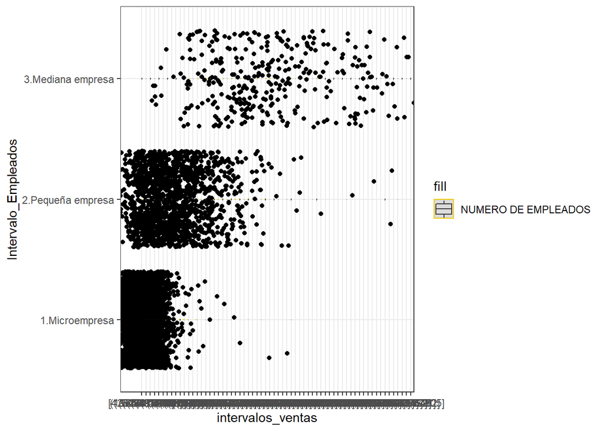

```r
GRAFICO_VIOLIN_NUMEROEMPLEADOS <- ggplot(data = tabla_contingencia, aes(x = intervalos_ventas, y = Intervalo_Empleados, fill = 'NUMERO DE EMPLEADOS')) +
  geom_violin(color = "gold2") +
  geom_jitter(alpha = 2, width = 5) +
  scale_fill_manual(values = c("gainsboro", "cyan1")) +
  geom_boxplot(width = 0.1) +
  theme_bw()

GRAFICO_VIOLIN_NUMEROEMPLEADOS
```

Separando las empresas segun el numero de empleados, es mas simple ver la diferencia que hay entre las empresas conforme mas empleados tengan. Podemos concluir, que hay relacion entre tener muchos empleados y muchas ventas o al inreves, pocos empleados y pocas ventas.

En el siguiente grafico, podemos ver un analisis avanzado de estadistica descriptiva y de correlacion entre las variables ventas y empleados segun el tipo de empresa.

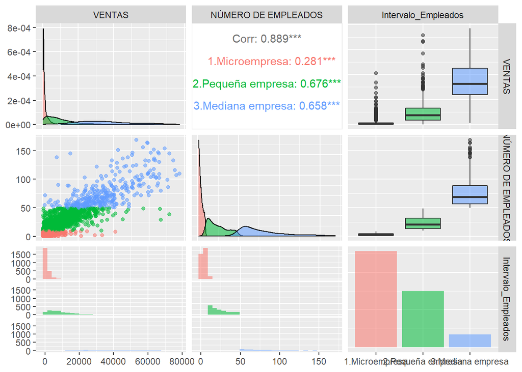

```r
Tabla_distribucion <- Tabla_INTERVALOS %>% select(VENTAS, `NÚMERO DE EMPLEADOS`, Intervalo_Empleados )

ggpairs(Tabla_distribucion[ , c(1:2, 3)], aes(colour = Tabla_distribucion$Intervalo_Empleados, alpha = 0.5), upper = list(continuous = wrap("cor", alignPercent = 0.5)))
```

-El grafico de ventas y el de empleados, se comportan de forma muy parecida, ambos graficos, la mayoria de microempresas tienen pocos empleados y pocas ventas, las pequeÃ±as empresas tienen un poco mas de empleados y a la vez mas ventas. Finalmente las empresas medianas estan mas dispersas, pero igualmente augmenta en numero de empleados y en ventas, siendo un poco mas llana el grafico de las ventas.

-En el diagrama de cajas llama la atencion, que en el caso de las medianas empresas, teniendo en cuenta las ventas, no hay ningun outlier, muestra que la media es bastante representativa, por eso, la caja es mucho mas amplia que las demas. Hay muchos outliers en las cajas de las micro y pequeÃ±as empresas. Si comparamos este grafico de cajas, con el de las ventas sin intervalo de empleados, vemos que separando las empresas por estos tres intervalos, hace que en cada intervalo, la media sea un poco mas representativa y que la media no este tan separada del Q3.

-La correlacion global es la mas fuerte de todas, pero destacamos, que en los intervalos de pequeña y mediana empresa, la correlacion es bastante fuerte. En el caso de microempresa, la correlacion indiviual es mucho mas baja. En el grafico de dispersion, muestra como las variables se comportan de forma parecida como mas numero de empleados tenga.

Creamos una tabla de contingencia con los valores esperados en caso de no existir dependencia entre ambas variables:

```r
chisq.test(Tabla_INTERVALOS$intervalos_ventas, Tabla_INTERVALOS$Intervalo_Empleados)$expected
```

```
##                                   Tabla_INTERVALOS$Intervalo_Empleados
## Tabla_INTERVALOS$intervalos_ventas 1.Microempresa 2.Pequeña empresa
##                    [4.924,1166.1]    1119.0924370       655.8991597
##                    (1166.1,2327.3]    309.4372019       181.3608903
##                    (2327.3,3488.5]    158.2084942        92.7258687
##                    (3488.5,4649.7]    118.6563707        69.5444015
##                    (4649.7,5810.9]     93.0638201        54.5446287
##                    (5810.9,6972.1]     70.9611628        41.5902794
##                    (6972.1,8133.3]     66.3079718        38.8630479
##                    (8133.3,9294.4]     69.7978651        40.9084715
##                    (9294.4,10456]      46.5319101        27.2723143
##                    (10456,11617]       40.7154213        23.8632750
##                    (11617,12778]       40.1337724        23.5223711
##                    (12778,13939]       37.8071769        22.1587554
##                    (13939,15100]       31.9906882        18.7497161
##                    (15100,16262]       29.6640927        17.3861004
##                    (16262,17423]       29.0824438        17.0451965
##                    (17423,18584]       27.9191460        16.3633886
##                    (18584,19745]       19.7760618        11.5907336
##                    (19745,20906]       19.1944129        11.2498297
##                    (20906,22068]       12.7962753         7.4998864
##                    (22068,23229]       12.2146264         7.1589825
##                    (23229,24390]       17.4494663        10.2271179
##                    (24390,25551]       11.6329775         6.8180786
##                    (25551,26712]       16.2861685         9.5453100
##                    (26712,27873]        9.3063820         5.4544629
##                    (27873,29035]       11.6329775         6.8180786
##                    (29035,30196]       12.2146264         7.1589825
##                    (30196,31357]        8.1430843         4.7726550
##                    (31357,32518]        6.3981376         3.7499432
##                    (32518,33679]       11.0513286         6.4771747
##                    (33679,34841]        8.1430843         4.7726550
##                    (34841,36002]        6.9797865         4.0908471
##                    (36002,37163]        5.2348399         3.0681354
##                    (37163,38324]        4.0715421         2.3863275
##                    (38324,39485]        7.5614354         4.4317511
##                    (39485,40647]        8.1430843         4.7726550
##                    (40647,41808]        4.0715421         2.3863275
##                    (41808,42969]        2.3265955         1.3636157
##                    (42969,44130]        1.1632978         0.6818079
```

[output cut: 77 more lines]

```
##                    (56903,58064]           0.2323416
##                    (58064,59226]           0.2323416
##                    (59226,60387]           0.4646832
##                    (60387,61548]           0.3097888
##                    (61548,62709]           0.3097888
##                    (62709,63870]           0.2323416
##                    (63870,65032]           0.2323416
##                    (65032,66193]           0.4646832
##                    (66193,67354]           0.2323416
##                    (68515,69676]           0.0774472
##                    (69676,70837]           0.1548944
##                    (70837,71999]           0.1548944
##                    (73160,74321]           0.0774472
##                    (74321,75482]           0.1548944
##                    (76643,77805]           0.0774472
```

La tabla con los valores esperados es muy distinta a la primera tabla de contingencia, esto denota una posible dependencia entre variables.

Usamos el Chi-cuadrado para determinar si existe dependencia entre las variables Ventas y empleados, usando los distintos intervalos encontrados anteriormente.

```r
chisq.test(Tabla_INTERVALOS$intervalos_ventas, Tabla_INTERVALOS$Intervalo_Empleados)
```

```
##
##  Pearson's Chi-squared test
##
## data:  Tabla_INTERVALOS$intervalos_ventas and Tabla_INTERVALOS$Intervalo_Empleados
## X-squared = 4880, df = 126, p-value < 2.2e-16
```

El p-value es = 0.00000000000000022 < 0.05 por lo que rechazamos la hipotesis inicial de que existe independencia entre las dos variables.

Al obtener un p-value casi nulo, existe una fuerte dependencia entre el tipo de empresa y las ventas obtenidas.

Podemos concluir que ambas variables presentan una fuerte relacion y una clara dependencia entre los empleados que trabajan en la empresa y las ventas que la empresa tiene.

2- MODELO DE REGRESION LINEAL

Determinaremos como varian las ventas, en funcion de las otras variables.

MODELO SIMPLE

En el modelo simple, estudiamos como varian las ventas en funcion del numero de empleados. Para determinar el modelo de regresion lineal simple de X (NUMERO DE EMPLEADOS) y Y (VENTAS), debemos conocer la pendiente de la recta y el intercepto.

```r
options(scipen = 100)
pendiente<-cov(Tabla$`NÚMERO DE EMPLEADOS`,Tabla$VENTAS)/var(Tabla$`NÚMERO DE EMPLEADOS`)
pendiente
```

```
## [1] 441.0807
```

```r
independiente<-mean(Tabla$VENTAS)-pendiente*mean(Tabla$`NÚMERO DE EMPLEADOS`)
independiente
```

```
## [1] -557.2968
```

La recta es igual a: VENTAS = NUMERO DE EMPLEADOS * 441.0807 - 557.2968

En la siguiente formula, creamos la recta que nombraremos regresion. Dibujamos los valores y la recta de regresion lineal simple.

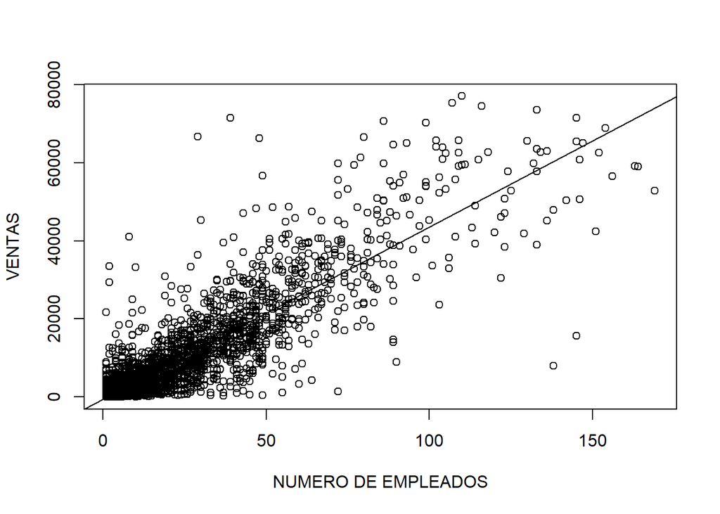

```r
regresion<-lm(VENTAS~`NÚMERO DE EMPLEADOS`, data=Tabla)
plot(Tabla$`NÚMERO DE EMPLEADOS`, Tabla$VENTAS, xlab="NUMERO DE EMPLEADOS", ylab="VENTAS")
abline(regresion)
```

Para determinar, como de eficiente es nuestra recta, calculamos el P-VALUE de nuestra variable X, el del intercepto, los valores residuales y el R^2:

```r
summary(regresion)
```

```
##
## Call:
## lm(formula = VENTAS ~ `NÚMERO DE EMPLEADOS`, data = Tabla)
##
## Residuals:
##    Min     1Q Median     3Q    Max
## -52328  -1645    -95    940  54820
##
## Coefficients:
##                       Estimate Std. Error t value             Pr(>|t|)
## (Intercept)           -557.297     95.160  -5.856        0.00000000507 ***
## `NÚMERO DE EMPLEADOS`  441.081      3.419 129.003 < 0.0000000000000002 ***
## ---
## Signif. codes:  0 '***' 0.001 '**' 0.01 '*' 0.05 '.' 0.1 ' ' 1
##
## Residual standard error: 5112 on 4401 degrees of freedom
## Multiple R-squared:  0.7909, Adjusted R-squared:  0.7908
## F-statistic: 1.664e+04 on 1 and 4401 DF,  p-value: < 0.00000000000000022
```

El F-statistic: (1, 4401) = 16640, por lo que alguna de las variables es significativa en el modelo. Aunque debemos tener en cuenta que el intervalo del F-test es muy grande. El p-value es muy pequeÃ±o, consideramos que los resultados de nuestro modelo son significativos.

Mirando los valores residuales, vemos que el min y el max son muy grandes, es decir, la maxima diferencia por debajo entre la realidad y nuestra prediccion es de -52.328, el maximo es de 54.820. El 50 % de las diferencias entre prediccion y realidad estaran entre un intervalo de [-1.645, 940].

Los P-VALUE del intercepto y del NUMERO DE EMPLEADOS es mucho mas pequeño que 0,05. En este caso rechazamos que el numero de empleados y el intercepto NO contribuyen en la prediccion de las ventas (Ho).

Al tener un R-squared cercano a 1, el modelo tiene alta capacidad explicativa de la recta, es decir, conociendo el numero de empleados, tenemos la capacidad de predecir por un valor aproximado el total de ventas de la empresa. En un 79 % la variabilidad de las ventas estan explicadas por el Nº de empleados.

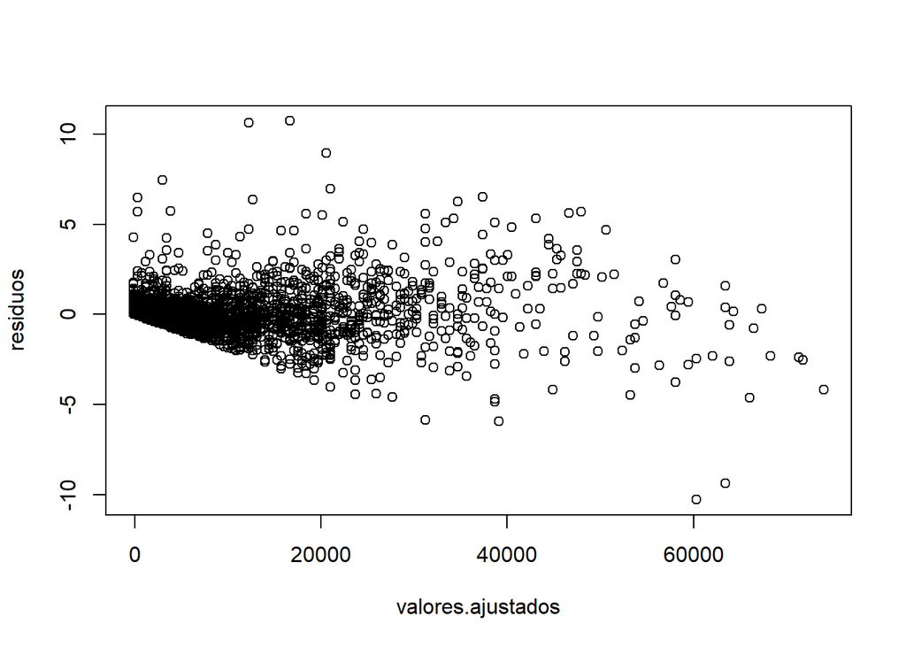

```r
residuos<- rstandard(regresion)
valores.ajustados<-fitted(regresion)
plot(valores.ajustados, residuos)
```

Podemos intuir un patron de los residuo, como mayores son las ventas, nuestro plot va tomando una forma mas acampanada. La homocedasticidad y la linealidad NO resultan hipotesis razonables.

Dibujamos el grafico Q-Q Plot, donde enfrenta los percentiles de nuestras dos variables. En caso de que los puntos esten muy alienados con la linea de los quantiles, podriamos pensar que nuestro model de regresion lineal es Normal.

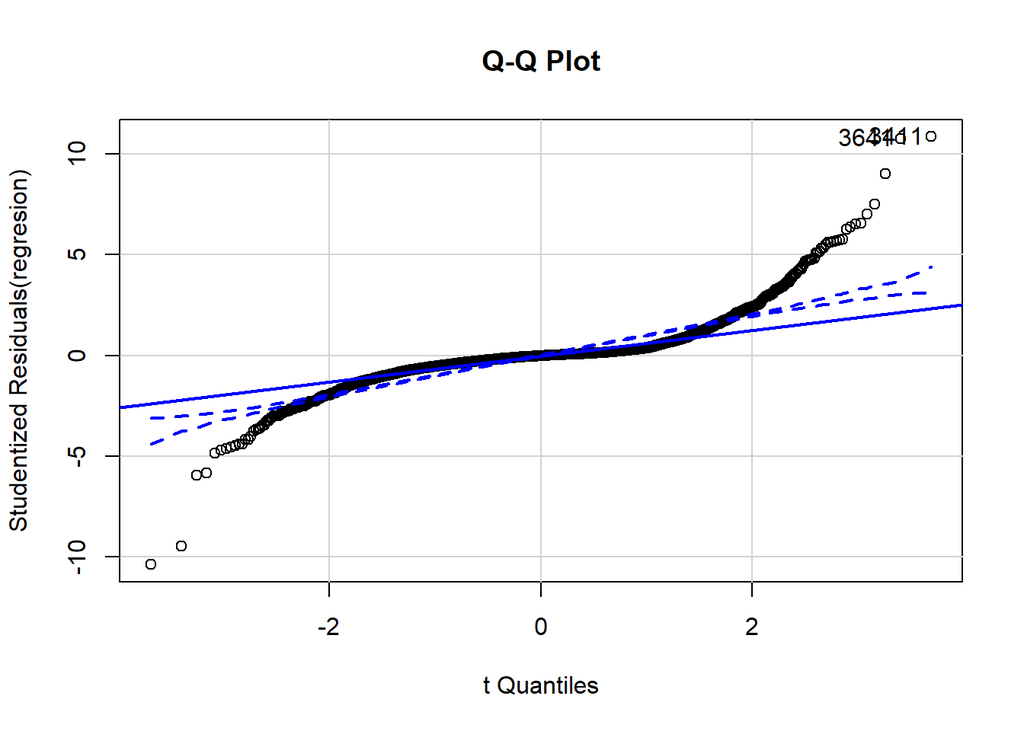

```
## [1] 3411 3641
```

```r
qqPlot(regresion, labels = row.names(DATOS), id.method = "identify", simulate = TRUE, main = "Q-Q Plot")
```

```r
skewness(residuos)
```

```
## [1] 1.349261
```

```r
kurtosis(residuos)
```

```
## [1] 19.7255
```

Los residuos de nuestra recta estan acumulados por debajo de la media y tienen una forma Leptocurtica.

Para poder hacer un diagnostico fiable de nuestra recta de regresion lineal, realizaremos los siguientes Test:

Test de Breusch-Pagan

```r
bptest(regresion)
```

```
##
##  studentized Breusch-Pagan test
##
## data:  regresion
## BP = 555.42, df = 1, p-value < 0.00000000000000022
```

El p-valor= 0,00000000000000022 < 0.05: Rechazamos la hipotesis nula de homocedasticidad. El model es HETEROCEDASTICO: La varianza de los errores del modelo de regresion lineal no es constante en todas las observaciones realizadas. Los errores de nuestras predicciones no seran comunes y tampoco constantes.

Test de Shapiro-Wilk:

```r
shapiro.test(regresion$residuals)
```

```
##
##  Shapiro-Wilk normality test
##
## data:  regresion$residuals
## W = 0.7601, p-value < 0.00000000000000022
```

El p-valor= 0,00000000000000022 < 0.05: Rechazamos la hipotesis inicial de normalidad. Nuestro modelo se comporta de una forma NO normal. Tal y como hemos comentado antes, con los coeficientes de curtosis y de asimedria fisher, nuestro modelo obtiene unos residuos que estan centradod por debajo de la media con una forma muy leptocurtica.

Test de Durbin-Watson:

```r
dwtest(regresion)
```

```
##
##  Durbin-Watson test
##
## data:  regresion
## DW = 1.9314, p-value = 0.01142
## alternative hypothesis: true autocorrelation is greater than 0
```

El p-valor= 0,011 < 0,05: Rechazamos H0, por lo que nuestro modelo si presenta autocorrelacion, es decir, los valores de la linea de regresion, presentan dependencia en cuanto al orden de obtencion.

Los residuos son dependientes entre si.

```r
bgtest(regresion,order = 2)
```

```
##
##  Breusch-Godfrey test for serial correlation of order up to 2
##
## data:  regresion
## LM test = 7.6064, df = 2, p-value = 0.0223
```

```r
bgtest(regresion,order = 1)
```

```
##
##  Breusch-Godfrey test for serial correlation of order up to 1
##
## data:  regresion
## LM test = 5.1741, df = 1, p-value = 0.02293
```

Como el P-value de segunda orden y de primera orden, es menor a 0,05, podemos concluir que los residuos tienen correlacion amplitud - amplitud (primera orden) y intensidad - intensidad ( segunda orden).

El modelo predictivo de regresion lineal simple -> VENTAS = NUMERO DE EMPLEADOS * 441.0807 - 557.2968 es heterocedastico, no se comporta de manera normal, presenta autocorrelacion y los residuos son dependientes.

Es cierto que nuestro modelo predictivo tiene un R^2 elevado, pero una vez realizado el diagnostico de los residuos, podemos concluir que el modelo necesita de mas variables para mejorar, ya que podriamos suponer que nuestro modelo pierde eficacia al poder subestimar el error estandar de los coeficientes, con lo que el R^2 pierde fiabilidad.

Realizamos el test gloval para finalizar con el diagnostico, incluso sabiendo que nuestro modelo no pasara las pruebas:

```r
gvlma(regresion)
```

```
##
## Call:
## lm(formula = VENTAS ~ `NÚMERO DE EMPLEADOS`, data = Tabla)
##
## Coefficients:
##           (Intercept)  `NÚMERO DE EMPLEADOS`
##                -557.3                  441.1
##
##
## ASSESSMENT OF THE LINEAR MODEL ASSUMPTIONS
## USING THE GLOBAL TEST ON 4 DEGREES-OF-FREEDOM:
## Level of Significance =  0.05
##
## Call:
##  gvlma(x = regresion)
##
##                        Value p-value                   Decision
## Global Stat        72638.687 0.00000 Assumptions NOT satisfied!
## Skewness            1348.743 0.00000 Assumptions NOT satisfied!
## Kurtosis           71209.811 0.00000 Assumptions NOT satisfied!
## Link Function          4.619 0.03163 Assumptions NOT satisfied!
## Heteroscedasticity    75.515 0.00000 Assumptions NOT satisfied!
```

Consideramos que el modelo lineal no es lo suficientemente bueno, en este modelo, el global stats indica que no existe linealidad entre las observaciones de nuestra tabla. Segun los tests de Skewness y Kurtosis no hay normalidad en nuestro modelo, con lo que entendemos, que para mejorar el modelo deberiamos transformar nuestros datos. El modelo no es adecuado para determinar las ventas.

Finalmente los residuos del modelo presentan heterocedasticidad, indicando que el R^2 resultante no es muy fiable al tener un modelo predictivo que mejora o empeora dependiendo del rango en que se encuentra.

MODELOS MULTIPLES

PRIMER MODELO MULTIPLE:

Creamos una tabla con todos los valores numericos relevantes para crear los modelos multiples:

```r
tabla_multiple <- Tabla %>% select(-REGISTRO, -PROVINCIA)
```

```r
modelo16 <-lm(VENTAS~`NÚMERO DE EMPLEADOS`+ rentabieco + rentabifin + endp + liq + PRODUCTIVIDAD + coe + edad + conce + numac + numpa + numest +  estp + grupo + fju, data=tabla_multiple)
summary(modelo16)
```

```
##
## Call:
## lm(formula = VENTAS ~ `NÚMERO DE EMPLEADOS` + rentabieco + rentabifin +
##     endp + liq + PRODUCTIVIDAD + coe + edad + conce + numac +
##     numpa + numest + estp + grupo + fju, data = tabla_multiple)
##
## Residuals:
##    Min     1Q Median     3Q    Max
## -48230  -1409    147   1167  46828
##
## Coefficients:
##                         Estimate Std. Error t value             Pr(>|t|)
## (Intercept)           -2983.4177   272.9568 -10.930 < 0.0000000000000002 ***
## `NÚMERO DE EMPLEADOS`   406.0657     4.5599  89.051 < 0.0000000000000002 ***
## rentabieco               16.7471     6.1274   2.733              0.00630 **
## rentabifin                0.6678     1.1426   0.584              0.55893
## endp                      6.2011     2.3324   2.659              0.00787 **
## liq                       5.4600    14.1497   0.386              0.69961
## PRODUCTIVIDAD            75.6840     3.6077  20.979 < 0.0000000000000002 ***
## coe                   44627.4979  3268.6178  13.653 < 0.0000000000000002 ***
## edad                    -23.3042     9.6995  -2.403              0.01632 *
## conce                     8.5592     1.4182   6.035        0.00000000172 ***
## numac                    17.3070    50.9912   0.339              0.73432
## numpa                   254.9339   103.0157   2.475              0.01337 *
## numest                  280.4778    63.8787   4.391        0.00001156000 ***
## estp                    304.5780   429.8153   0.709              0.47859
## grupo                   593.5776   324.5880   1.829              0.06751 .
## fju                     577.4850   194.6838   2.966              0.00303 **
## ---
## Signif. codes:  0 '***' 0.001 '**' 0.01 '*' 0.05 '.' 0.1 ' ' 1
##
## Residual standard error: 4678 on 4387 degrees of freedom
## Multiple R-squared:  0.8254, Adjusted R-squared:  0.8248
## F-statistic:  1383 on 15 and 4387 DF,  p-value: < 0.00000000000000022
```

Este modelo es mejor que el modelo lineal simple, la bondad del ajuste a subido de 0.7908 a 0.8248. Nuestro modelo es significativo, la mayoria de p-valores de las variables estan por debajo de 0.05, indicando que aportan valor en nuestro modelo predictivo.

Las variables Numero de empleados, Productividad, coe ( cuota de mercado por provincias ), conce ( numero de franquicias por municipio) y numest ( numero de establecimientos ) son las variables que aportan mas significado a nuestro modelo, haciendo que el R^2 del modelo sea bastante alto.

Realizamos el proceso step, para quedarnos con todas las variables significativas para mejorar el modelo:

```r
step(modelo16, direction = "backward")
```

```
## Start:  AIC=74432.37
## VENTAS ~ `NÚMERO DE EMPLEADOS` + rentabieco + rentabifin + endp +
##     liq + PRODUCTIVIDAD + coe + edad + conce + numac + numpa +
##     numest + estp + grupo + fju
##
##                         Df    Sum of Sq          RSS   AIC
## - numac                  1      2521119  96010283850 74430
## - liq                    1      3258642  96011021373 74431
## - rentabifin             1      7476013  96015238744 74431
## - estp                   1     10989351  96018752082 74431
## <none>                                   96007762731 74432
## - grupo                  1     73186141  96080948872 74434
## - edad                   1    126330065  96134092796 74436
## - numpa                  1    134025502  96141788233 74437
## - endp                   1    154691280  96162454011 74437
## - rentabieco             1    163480772  96171243503 74438
## - fju                    1    192557612  96200320343 74439
## - numest                 1    421913611  96429676342 74450
## - conce                  1    797177083  96804939814 74467
## - coe                    1   4079580412 100087343143 74614
## - PRODUCTIVIDAD          1   9631444160 105639206891 74851
## - `NÚMERO DE EMPLEADOS`  1 173548437216 269556199948 78976
##
## Step:  AIC=74430.48
## VENTAS ~ `NÚMERO DE EMPLEADOS` + rentabieco + rentabifin + endp +
##     liq + PRODUCTIVIDAD + coe + edad + conce + numpa + numest +
##     estp + grupo + fju
##
##                         Df    Sum of Sq          RSS   AIC
## - liq                    1      3144988  96013428838 74429
## - rentabifin             1      7364621  96017648471 74429
## - estp                   1     11222628  96021506477 74429
## <none>                                   96010283850 74430
## - grupo                  1     73790962  96084074812 74432
## - edad                   1    124403936  96134687786 74434
## - numpa                  1    138984463  96149268312 74435
## - endp                   1    152689388  96162973238 74435
## - rentabieco             1    163767399  96174051249 74436
## - fju                    1    204149580  96214433430 74438
## - numest                 1    425050166  96435334016 74448
```

[output cut: 47 more lines]

```
##     coe + edad + conce + numpa + numest + grupo + fju
##
##                         Df    Sum of Sq          RSS   AIC
## <none>                                   96031865077 74425
## - grupo                  1     69423889  96101288967 74427
## - edad                   1    131128023  96162993100 74429
## - numpa                  1    144656289  96176521366 74430
## - endp                   1    153582731  96185447808 74431
## - rentabieco             1    160157798  96192022876 74431
## - fju                    1    205238998  96237104076 74433
## - numest                 1    501231295  96533096372 74446
## - conce                  1    806536488  96838401565 74460
## - coe                    1   4177077294 100208942372 74611
## - PRODUCTIVIDAD          1   9742920541 105774785618 74849
## - `NÚMERO DE EMPLEADOS`  1 175417494779 271449359857 78999
```

```
##
## Call:
## lm(formula = VENTAS ~ `NÚMERO DE EMPLEADOS` + rentabieco + endp +
##     PRODUCTIVIDAD + coe + edad + conce + numpa + numest + grupo +
##     fju, data = tabla_multiple)
##
## Coefficients:
##           (Intercept)  `NÚMERO DE EMPLEADOS`             rentabieco
##             -2950.691                406.035                 16.555
##                  endp          PRODUCTIVIDAD                    coe
##                 6.078                 75.872              44866.558
##                  edad                  conce                  numpa
##               -23.581                  8.602                263.147
##                numest                  grupo                    fju
##               293.519                576.652                589.088
```

Nos quedamos con el modelo con el valor AIC menor de todos:

```r
modeloSTEP <-lm(VENTAS ~ `NÚMERO DE EMPLEADOS` + rentabieco + endp + PRODUCTIVIDAD + coe + edad + conce + numpa + numest + grupo + fju, data=tabla_multiple)
summary(modeloSTEP)
```

```
##
## Call:
## lm(formula = VENTAS ~ `NÚMERO DE EMPLEADOS` + rentabieco + endp +
##     PRODUCTIVIDAD + coe + edad + conce + numpa + numest + grupo +
##     fju, data = tabla_multiple)
##
## Residuals:
##    Min     1Q Median     3Q    Max
## -48220  -1406    143   1160  47059
##
## Coefficients:
##                        Estimate Std. Error t value             Pr(>|t|)
## (Intercept)           -2950.691    261.601 -11.279 < 0.0000000000000002 ***
## `NÚMERO DE EMPLEADOS`   406.035      4.534  89.559 < 0.0000000000000002 ***
## rentabieco               16.555      6.118   2.706              0.00683 **
## endp                      6.078      2.294   2.650              0.00808 **
## PRODUCTIVIDAD            75.872      3.595  21.107 < 0.0000000000000002 ***
## coe                   44866.558   3246.478  13.820 < 0.0000000000000002 ***
## edad                    -23.581      9.630  -2.449              0.01438 *
## conce                     8.602      1.416   6.073        0.00000000136 ***
## numpa                   263.147    102.319   2.572              0.01015 *
## numest                  293.519     61.312   4.787        0.00000174576 ***
## grupo                   576.652    323.657   1.782              0.07487 .
## fju                     589.088    192.299   3.063              0.00220 **
## ---
## Signif. codes:  0 '***' 0.001 '**' 0.01 '*' 0.05 '.' 0.1 ' ' 1
##
## Residual standard error: 4677 on 4391 degrees of freedom
## Multiple R-squared:  0.8254, Adjusted R-squared:  0.8249
## F-statistic:  1887 on 11 and 4391 DF,  p-value: < 0.00000000000000022
```

Con el modelo STEP definitivo continuamos teninedo un modelo significativo y mejoramos muy poco la bondad del ajuste, pasamos de 0.8248 a 0.8249.

Realizamos el gvlma test para conocer si nuestro modelo es lo suficientemente bueno como parece:

```r
gvlma(modeloSTEP)
```

```
##
## Call:
## lm(formula = VENTAS ~ `NÚMERO DE EMPLEADOS` + rentabieco + endp +
##     PRODUCTIVIDAD + coe + edad + conce + numpa + numest + grupo +
##     fju, data = tabla_multiple)
##
## Coefficients:
##           (Intercept)  `NÚMERO DE EMPLEADOS`             rentabieco
##             -2950.691                406.035                 16.555
##                  endp          PRODUCTIVIDAD                    coe
##                 6.078                 75.872              44866.558
##                  edad                  conce                  numpa
##               -23.581                  8.602                263.147
##                numest                  grupo                    fju
##               293.519                576.652                589.088
##
##
## ASSESSMENT OF THE LINEAR MODEL ASSUMPTIONS
## USING THE GLOBAL TEST ON 4 DEGREES-OF-FREEDOM:
## Level of Significance =  0.05
##
## Call:
##  gvlma(x = modeloSTEP)
##
##                       Value              p-value                   Decision
## Global Stat        66207.97 0.000000000000000000 Assumptions NOT satisfied!
## Skewness             694.36 0.000000000000000000 Assumptions NOT satisfied!
## Kurtosis           65442.57 0.000000000000000000 Assumptions NOT satisfied!
## Link Function          1.15 0.283503456754683469    Assumptions acceptable.
## Heteroscedasticity    69.89 0.000000000000000111 Assumptions NOT satisfied!
```

El unico supuesto aceptable, al tener un p-valor superior a 0.05, es el de Link Function, es decir, nuestro modelo es adecuado para predecir las ventas.

¿Podemos mejorar el modelo si introducimos los intervalos de los empleados, es decir, la division por micro, pequeña y mediana empresa?

```r
modelointervalo <-lm(VENTAS~ Intervalo_Empleados +`NÚMERO DE EMPLEADOS` + rentabieco + endp + PRODUCTIVIDAD + coe + edad + conce + numpa + numest + grupo + fju, data=Tabla_INTERVALOS)
summary(modelointervalo)
```

```
##
## Call:
## lm(formula = VENTAS ~ Intervalo_Empleados + `NÚMERO DE EMPLEADOS` +
##     rentabieco + endp + PRODUCTIVIDAD + coe + edad + conce +
##     numpa + numest + grupo + fju, data = Tabla_INTERVALOS)
##
## Residuals:
##    Min     1Q Median     3Q    Max
## -47651  -1276      0   1005  47880
##
## Coefficients:
##                                       Estimate Std. Error t value
## (Intercept)                          -2552.134    263.590  -9.682
## Intervalo_Empleados2.Pequeña empresa  -732.111    217.955  -3.359
## Intervalo_Empleados3.Mediana empresa  2195.057    578.160   3.797
## `NÚMERO DE EMPLEADOS`                  383.842      7.477  51.338
## rentabieco                              17.317      6.068   2.854
## endp                                     4.525      2.283   1.982
## PRODUCTIVIDAD                           73.499      3.578  20.543
## coe                                  46366.922   3227.043  14.368
## edad                                   -14.936      9.635  -1.550
## conce                                    8.563      1.405   6.096
## numpa                                  243.333    101.486   2.398
## numest                                 301.661     60.807   4.961
## grupo                                  771.452    322.202   2.394
## fju                                    809.101    193.970   4.171
##                                                  Pr(>|t|)
## (Intercept)                          < 0.0000000000000002 ***
## Intervalo_Empleados2.Pequeña empresa             0.000789 ***
## Intervalo_Empleados3.Mediana empresa             0.000149 ***
## `NÚMERO DE EMPLEADOS`                < 0.0000000000000002 ***
## rentabieco                                       0.004339 **
## endp                                             0.047514 *
## PRODUCTIVIDAD                        < 0.0000000000000002 ***
## coe                                  < 0.0000000000000002 ***
## edad                                             0.121174
## conce                                       0.00000000118 ***
## numpa                                            0.016540 *
## numest                                      0.00000072809 ***
## grupo                                            0.016693 *
## fju                                         0.00003087591 ***
## ---
## Signif. codes:  0 '***' 0.001 '**' 0.01 '*' 0.05 '.' 0.1 ' ' 1
##
## Residual standard error: 4637 on 4389 degrees of freedom
## Multiple R-squared:  0.8284, Adjusted R-squared:  0.8279
## F-statistic:  1630 on 13 and 4389 DF,  p-value: < 0.00000000000000022
```

Usando la cataregorizacion de las empresas en nuestro modelo, la bondad del ajuste del modelo es mayor que el anterior. De todos los modelos presentados hasta ahora, este es el modelo con un R^2 mas grande de todos.

```r
gvlma(modelointervalo)
```

```
##
## Call:
## lm(formula = VENTAS ~ Intervalo_Empleados + `NÚMERO DE EMPLEADOS` +
##     rentabieco + endp + PRODUCTIVIDAD + coe + edad + conce +
##     numpa + numest + grupo + fju, data = Tabla_INTERVALOS)
##
## Coefficients:
##                          (Intercept)  Intervalo_Empleados2.Pequeña empresa
##                            -2552.134                              -732.111
## Intervalo_Empleados3.Mediana empresa                 `NÚMERO DE EMPLEADOS`
##                             2195.057                               383.842
##                           rentabieco                                  endp
##                               17.317                                 4.525
##                        PRODUCTIVIDAD                                   coe
##                               73.499                             46366.922
##                                 edad                                 conce
##                              -14.936                                 8.563
##                                numpa                                numest
##                              243.333                               301.661
##                                grupo                                   fju
##                              771.452                               809.101
##
##
## ASSESSMENT OF THE LINEAR MODEL ASSUMPTIONS
## USING THE GLOBAL TEST ON 4 DEGREES-OF-FREEDOM:
## Level of Significance =  0.05
##
## Call:
##  gvlma(x = modelointervalo)
##
##                        Value p-value                   Decision
## Global Stat        72099.077 0.00000 Assumptions NOT satisfied!
## Skewness             697.976 0.00000 Assumptions NOT satisfied!
## Kurtosis           71323.377 0.00000 Assumptions NOT satisfied!
## Link Function          6.067 0.01377 Assumptions NOT satisfied!
## Heteroscedasticity    71.656 0.00000 Assumptions NOT satisfied!
```

En el modelo con el intervalo de empresas, hemos ganado un poco de R^2 pero este modelo no es adecuado para medir las ventas.

Vamos a intentar transformar nuestros datos, para conseguir un mejor modelo que el anterior

```r
skewness(Tabla$VENTAS)
```

```
## [1] 2.814779
```

Al tener un coeficiente de asimetria fisher positivo, creamos una nueva tabla con el logaritmo de las ventas para equiparar los datos que analizamos:

```r
tabla_multiplelog <- transform(tabla_multiple, VENTAS=log(VENTAS))
tabla_multiplelog %>% filter(is.na(tabla_multiple)) %>% count()
```

```
##   n
## 1 0
```

Vamos a crear el mismo modelo que el modeloSTEP pero utilizando la nueva tabla:

```r
modeloSTEPlog <-lm(VENTAS ~ NÚMERO.DE.EMPLEADOS + rentabieco + endp + PRODUCTIVIDAD + coe + edad + conce + numpa + numest + grupo + fju, data=tabla_multiplelog)
summary(modeloSTEPlog)
```

```
##
## Call:
## lm(formula = VENTAS ~ NÚMERO.DE.EMPLEADOS + rentabieco + endp +
##     PRODUCTIVIDAD + coe + edad + conce + numpa + numest + grupo +
##     fju, data = tabla_multiplelog)
##
## Residuals:
##     Min      1Q  Median      3Q     Max
## -6.4208 -0.5809  0.1077  0.7584  2.6765
##
## Coefficients:
##                       Estimate Std. Error t value             Pr(>|t|)
## (Intercept)          6.1579101  0.0599019 102.800 < 0.0000000000000002 ***
## NÚMERO.DE.EMPLEADOS  0.0422012  0.0010381  40.651 < 0.0000000000000002 ***
## rentabieco           0.0102340  0.0014008   7.306    0.000000000000326 ***
## endp                -0.0037098  0.0005252  -7.064    0.000000000001878 ***
## PRODUCTIVIDAD        0.0223737  0.0008231  27.181 < 0.0000000000000002 ***
## coe                  8.6731197  0.7433840  11.667 < 0.0000000000000002 ***
## edad                 0.0138932  0.0022051   6.300    0.000000000326119 ***
## conce                0.0011819  0.0003244   3.644             0.000272 ***
## numpa               -0.0361850  0.0234292  -1.544             0.122554
## numest               0.0640772  0.0140392   4.564    0.000005152093096 ***
## grupo                0.4373129  0.0741115   5.901    0.000000003891059 ***
## fju                  0.4871538  0.0440329  11.063 < 0.0000000000000002 ***
## ---
## Signif. codes:  0 '***' 0.001 '**' 0.01 '*' 0.05 '.' 0.1 ' ' 1
##
## Residual standard error: 1.071 on 4391 degrees of freedom
## Multiple R-squared:  0.6445, Adjusted R-squared:  0.6436
## F-statistic: 723.8 on 11 and 4391 DF,  p-value: < 0.00000000000000022
```

Hemos perdido mucha bondad del ajuste, vamos a revisar si hay algun cambio en el diagnostico del modelo:

```r
gvlma(modeloSTEPlog)
```

```
##
## Call:
## lm(formula = VENTAS ~ NÚMERO.DE.EMPLEADOS + rentabieco + endp +
##     PRODUCTIVIDAD + coe + edad + conce + numpa + numest + grupo +
##     fju, data = tabla_multiplelog)
##
## Coefficients:
##         (Intercept)  NÚMERO.DE.EMPLEADOS           rentabieco
##            6.157910             0.042201             0.010234
##                endp        PRODUCTIVIDAD                  coe
##           -0.003710             0.022374             8.673120
##                edad                conce                numpa
##            0.013893             0.001182            -0.036185
##              numest                grupo                  fju
##            0.064077             0.437313             0.487154
##
##
## ASSESSMENT OF THE LINEAR MODEL ASSUMPTIONS
## USING THE GLOBAL TEST ON 4 DEGREES-OF-FREEDOM:
## Level of Significance =  0.05
##
## Call:
##  gvlma(x = modeloSTEPlog)
##
##                         Value p-value                   Decision
## Global Stat        2944.94186  0.0000 Assumptions NOT satisfied!
## Skewness            657.85104  0.0000 Assumptions NOT satisfied!
## Kurtosis            682.19663  0.0000 Assumptions NOT satisfied!
## Link Function      1604.86666  0.0000 Assumptions NOT satisfied!
## Heteroscedasticity    0.02753  0.8682    Assumptions acceptable.
```

El modelo usando el log. de ventas, no es bueno para predecir las ventas, pero es homocedastico, es decir, los residuos no estan explicados por las variables.

Al perder tanta bondad del ajuste, suponemos que usando el log. de ventas hemos perdido mucho en precision, por lo que no nos interesa usar esta nueva tabla.

Creamos un modelo con una nueva variable: Productividad * Empleado

```r
modelofinal <-lm(VENTAS ~ `NÚMERO DE EMPLEADOS`*PRODUCTIVIDAD+ rentabieco + endp + coe + edad + conce + numac + numpa + numest +  estp + grupo + fju, data=Tabla_INTERVALOS)
summary(modelofinal)
```

```
##
## Call:
## lm(formula = VENTAS ~ `NÚMERO DE EMPLEADOS` * PRODUCTIVIDAD +
##     rentabieco + endp + coe + edad + conce + numac + numpa +
##     numest + estp + grupo + fju, data = Tabla_INTERVALOS)
##
## Residuals:
##    Min     1Q Median     3Q    Max
## -29841   -784     83    568  37252
##
## Coefficients:
##                                      Estimate Std. Error t value
## (Intercept)                         -909.8301   171.6311  -5.301
## `NÚMERO DE EMPLEADOS`                 87.8141     4.9399  17.776
## PRODUCTIVIDAD                         -7.2933     2.5257  -2.888
## rentabieco                             3.5229     3.9159   0.900
## endp                                   1.5930     1.4714   1.083
## coe                                 5572.0594  2145.4542   2.597
## edad                                 -11.1360     6.1780  -1.803
## conce                                  6.2933     0.9067   6.941
## numac                                -40.8680    32.5976  -1.254
## numpa                                277.9958    65.8363   4.223
## numest                               190.1850    40.8516   4.656
## estp                                 345.3378   274.7817   1.257
## grupo                               -138.1286   207.6638  -0.665
## fju                                  252.2572   124.5183   2.026
## `NÚMERO DE EMPLEADOS`:PRODUCTIVIDAD   24.6365     0.3092  79.668
##                                                 Pr(>|t|)
## (Intercept)                             0.00000012077489 ***
## `NÚMERO DE EMPLEADOS`               < 0.0000000000000002 ***
## PRODUCTIVIDAD                                    0.00390 **
## rentabieco                                       0.36837
## endp                                             0.27900
## coe                                              0.00943 **
## edad                                             0.07153 .
## conce                                   0.00000000000446 ***
## numac                                            0.21001
## numpa                                   0.00002464684869 ***
## numest                                  0.00000332716682 ***
## estp                                             0.20890
## grupo                                            0.50599
## fju                                              0.04284 *
## `NÚMERO DE EMPLEADOS`:PRODUCTIVIDAD < 0.0000000000000002 ***
## ---
## Signif. codes:  0 '***' 0.001 '**' 0.01 '*' 0.05 '.' 0.1 ' ' 1
##
## Residual standard error: 2991 on 4388 degrees of freedom
## Multiple R-squared:  0.9286, Adjusted R-squared:  0.9284
## F-statistic:  4078 on 14 and 4388 DF,  p-value: < 0.00000000000000022
```

Este modelo, aunque tiene varias variables no significativas, es el unico que tiene un R^2 tan alto como 0.9284 y a la vez, un F-statistic = 4078 entre [14, 4388], con lo que nuestro modelo es muy significativo al tener un p-value con un valor casi nulo.

Con el modelo actual, podemos explicar el 93 % de la variabilidad de las ventas con LA variabilidad del resto de variables.

Vemos los posibles valores influyentes de nuestro modelo:

```r
summary(influence.measures(modelofinal))
```

```
## Potentially influential observations of
##   lm(formula = VENTAS ~ `NÚMERO DE EMPLEADOS` * PRODUCTIVIDAD +      rentabieco + endp + coe + edad + conce + numac + numpa +      numest + estp + grupo + fju, data = Tabla_INTERVALOS) :
##
##      dfb.1_ dfb.`NÚMERODEEMPLEADOS` dfb.PROD dfb.rntb dfb.endp dfb.coe dfb.edad
## 2     0.01  -0.02                   -0.06     0.01     0.01     0.00   -0.01
## 6     0.03   0.01                   -0.01     0.00    -0.01    -0.04   -0.04
## 16    0.05  -0.16                   -0.03     0.00    -0.02    -0.27    0.09
## 36    0.02   0.00                    0.01     0.02    -0.01     0.01   -0.01
## 39    0.00   0.01                    0.00     0.00     0.00    -0.01   -0.01
## 48    0.00   0.00                    0.00     0.00     0.00     0.00    0.00
## 59    0.01   0.04                    0.01    -0.01     0.00    -0.01    0.01
## 60    0.02  -0.03                   -0.15    -0.01     0.00     0.01   -0.01
## 69    0.04   0.00                    0.00    -0.05    -0.04     0.00   -0.01
## 70    0.00   0.00                    0.00     0.00     0.00     0.00    0.00
## 109   0.00   0.00                    0.00    -0.01     0.00     0.00    0.00
```

[output cut: 1518 more lines]

Hay muchisimos valores influyentes que puedan estar afectando a nuestro modelo.

Test gvlma:

```r
gvlma(modelofinal)
```

```
##
## Call:
## lm(formula = VENTAS ~ `NÚMERO DE EMPLEADOS` * PRODUCTIVIDAD +
##     rentabieco + endp + coe + edad + conce + numac + numpa +
##     numest + estp + grupo + fju, data = Tabla_INTERVALOS)
##
## Coefficients:
##                         (Intercept)                `NÚMERO DE EMPLEADOS`
##                            -909.830                               87.814
##                       PRODUCTIVIDAD                           rentabieco
##                              -7.293                                3.523
##                                endp                                  coe
##                               1.593                             5572.059
##                                edad                                conce
##                             -11.136                                6.293
##                               numac                                numpa
##                             -40.868                              277.996
##                              numest                                 estp
##                             190.185                              345.338
##                               grupo                                  fju
##                            -138.129                              252.257
## `NÚMERO DE EMPLEADOS`:PRODUCTIVIDAD
##                              24.637
##
##
## ASSESSMENT OF THE LINEAR MODEL ASSUMPTIONS
## USING THE GLOBAL TEST ON 4 DEGREES-OF-FREEDOM:
## Level of Significance =  0.05
##
## Call:
##  gvlma(x = modelofinal)
##
##                          Value          p-value                   Decision
## Global Stat        137167.2745 0.00000000000000 Assumptions NOT satisfied!
## Skewness             1171.9584 0.00000000000000 Assumptions NOT satisfied!
## Kurtosis           135949.3152 0.00000000000000 Assumptions NOT satisfied!
## Link Function           0.4809 0.48801253719773    Assumptions acceptable.
## Heteroscedasticity     45.5201 0.00000000001511 Assumptions NOT satisfied!
```

El modelo final es el siguiente:

VENTAS = 87.8 * Empleados - 7.3 * Productividad + 3.5 * rentabieco + 1.6 * endp + 5572 * coe - 11.1 * edad + 6.3 * conce - 40.9 * numac + 278 * numpa + 190.2 * numest + 345.3 * estp - 138.1 * grupo + 252.3 * fju + 24.6 * (Empleados * Productividad) -909.83

Si todos los valores de las variables fueran 0, empezariamos con unas ventas de -909.83.

Los empleados hacen subir las ventas, como mas empleados tengamos, mas ventas tendra la empresa, al contrario pasa con la productividad, como mas productividad, menos ventas. Esto parece complicado de entender, pero segun nuestro modelo, como menos empleados tengamos la productividad es mayor comparada con empresas con muchos empleados, es por eso que la productividad resta a las ventas pronosticadas.

La variable productividad por empleado, en este caso si que hace subir las ventas totales. Junto a los empleados, son las variables que mas valor aportan a nuestro modelo.

El resto de variables que ayudan a crecer el numero de ventas, la gran mayoria estan correlacionados con la cantidad de empleados de forma positiva. Es el caso de COE (cuota de mercado por provincias), como mas grande sea la cuota de mercado, segun nuestro modelo tendra mas ventas.

Para poder conseguir mas ventas, es importante ser una empresa grande, como mas empleados mas probabilidad de obtener mas ventas, pero a la vez, se reducira la productividad.

En caso de que el numero de accionistas de la empresa sea elevado, forme parte de un grupo y lleve muchos años abierta, hara que el pronostico de las ventas sea menor comparado con una empresa joven, sin accionistas y que no pertenece a un grupo manteniendo el resto de variables iguales.

Lo contrario pasa en caso de que la empresa tenga varios establecimientos distribuidos por distintas provincias y que sean una sociedad anonima, haran crecer las ventas manteniendo el resto de variables iguales.

Podemos concluir que para tener mas ventas, contratar nuevos empleados no es la unica solucion, es importante distribuirlos por distintas localidades, con varios establecimientos e intentado ocupar una amplia cuota de mercado.

3- Medir mediante inferencia estadistica, si las ventas de Madrid y Barcelona se comportan de forma diferente:

Creamos una tabla con todas las variables filtrando por las provincias de Madrid y Barcelona. Contamos el total de empresas de Madrid y Barcelona:

```r
Tabla %>% filter(PROVINCIA == 'Barcelona' | PROVINCIA == 'Madrid') -> TablaBM
TablaBM %>% filter(PROVINCIA=='Barcelona') %>% count()
```

```
## # A tibble: 1 x 1
##       n
##   <int>
## 1   546
```

Nuestra tabla tiene un total de 546 empresas en Barcelona.

```r
TablaBM %>% filter(PROVINCIA=='Madrid') %>% count()
```

```
## # A tibble: 1 x 1
##       n
##   <int>
## 1   473
```

Nuestra tabla tiene un total de 473 empresas en Madrid.

Creamos un grafico violin del total de ventas para visualizar la dispersion de ambas provincias:

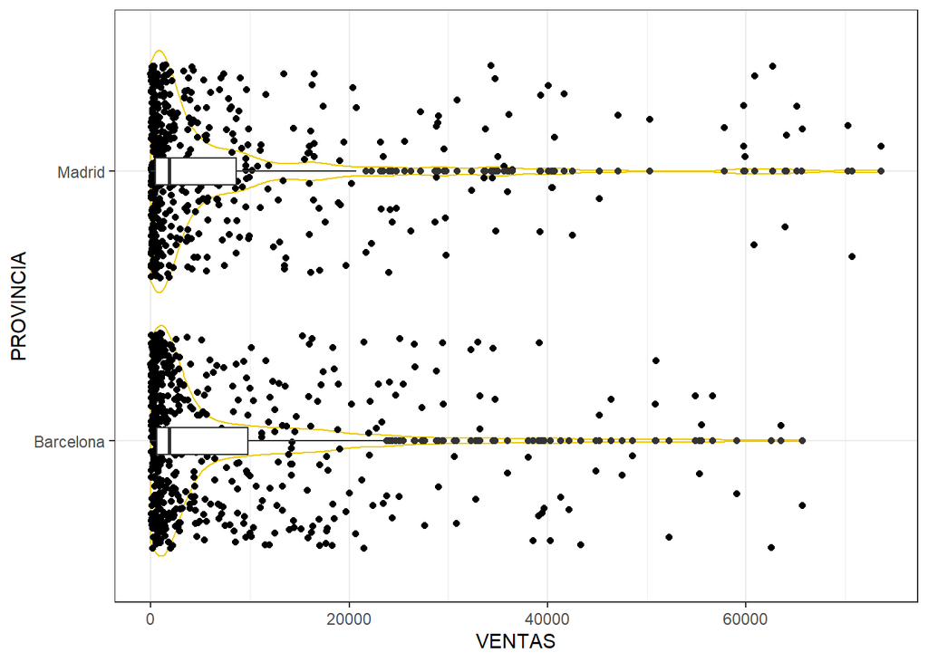

```r
GRAFICO_VIOLIN_VENTAS<- ggplot(data = TablaBM, aes(x = VENTAS, y = PROVINCIA)) +
  geom_violin(color = "gold2") +
  geom_jitter(alpha = 2, width = 5) +
  scale_fill_manual(values = c("gainsboro", "cyan1")) +
  geom_boxplot(width = 0.1) +
  theme_bw()

GRAFICO_VIOLIN_VENTAS
```

A simple vista es complicado determinar si existe alguna diferencia evidente entre el comportamiento de las ventas de nuestra tabla.

Es cierto, que en Madrid tiene algun outlier superior al de Barcelona, pero en general el grafico representa dispersiones muy parecidas entre si.

Creamos una tabla con las ventas de Barcelona:

```r
Tabla %>%  filter(PROVINCIA=='Barcelona') %>%select(VENTAS) ->VENTAS_BARCELONA
names(VENTAS_BARCELONA) <- 'Ventas_Barcelona'
VENTAS_BARCELONA
```

```
## # A tibble: 546 x 1
##    Ventas_Barcelona
##               <dbl>
##  1           11235.
##  2            2819.
##  3             527.
##  4             564.
##  5           30803.
##  6            1010.
##  7            2791.
##  8           28774.
##  9           39061.
## 10            5638.
## # ... with 536 more rows
```

Creamos una tabla con las ventas de Madrid:

```r
Tabla %>%  filter(PROVINCIA=='Madrid') %>%select(VENTAS) ->VENTAS_MADRID
names(VENTAS_MADRID) <- 'Ventas_Madrid'
VENTAS_MADRID
```

```
## # A tibble: 473 x 1
##    Ventas_Madrid
##            <dbl>
##  1         1011.
##  2         3617.
##  3        10199.
##  4         1023.
##  5         9784.
##  6         1313.
##  7         4123.
##  8         6731.
##  9         1735.
## 10         4714.
## # ... with 463 more rows
```

El numero de empresas totales de Madrid y Barcelona coincide con los valores mencionados anteriormente.

Diagrama de Bigotes de las ventas de Madrid:

```r
boxplot2<-function(x,y)
{
  stats=boxplot.stats(x)$stats
  f=fivenum(x)
  stats2<-c(f[1],stats,f[5])
  stats3<-c(f[1],f[5])

  boxplot(x,main=y,col="blue4")
  abline(h=stats[1],lty=2,col="red4")
  abline(h=stats[5],lty=2,col="red4")
  text(rep(1.3,5),stats,labels=c('BIGOTE INF.','Q1','Q2','Q3','BIGOTE SUP.'), col="red4")
  text(rep(0.6,7),stats2,labels=round(stats2,digits=4),cex=0.6, col= "blue4")
  text(rep(0.9,2),stats3,labels=c('MINIMO','MAXIMO'), col="red4")
  }
par(mfrow=c(1,2))
```

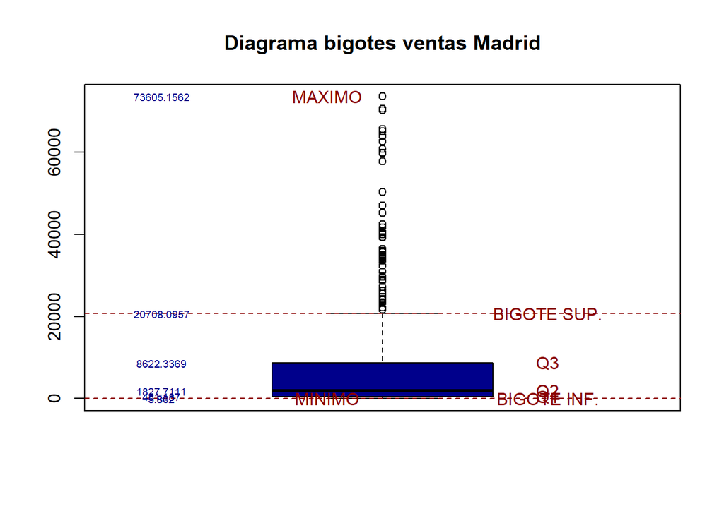

```r
boxplot2(VENTAS_MADRID$Ventas_Madrid, 'Diagrama bigotes ventas Madrid')
```

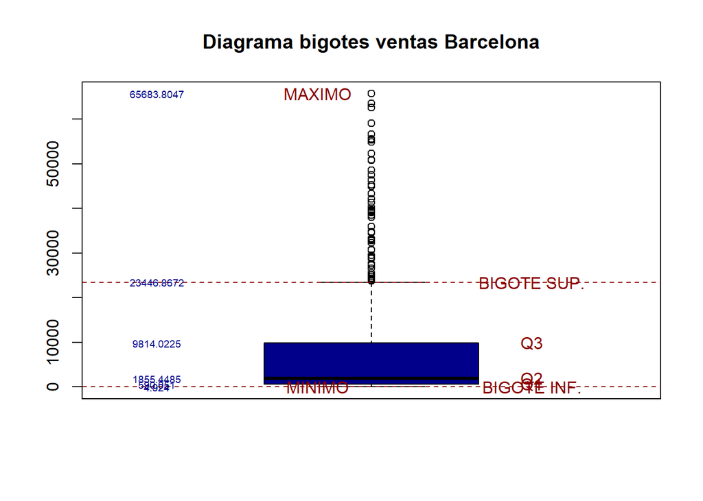

```r
boxplot2(VENTAS_BARCELONA$Ventas_Barcelona, 'Diagrama bigotes ventas Barcelona')
```

Los dos diagramas tienen el Q1 y el Q2 muy junto, el bigote inferior esta muy cerca del Q1 y no tienen outliers por debajo. Muchos outliers en la parte superior de las ventas de Madrid y Barcelona.

Entre el Q2 y el Q3 de las ventas de Barcelona hay un poco mas de dispersion que en los mismos puntos de las ventas de Madrid, aunque en Madrid el maximo de ventas es superior al maximo de ventas de Barcelona, el bigote superior de Barcelona es mayor que el de Madrid.

En general, son dos dibujos muy parecidos, aunque con pequeños matices.

```r
mean(VENTAS_BARCELONA$Ventas_Barcelona)
```

```
## [1] 7599.873
```

```r
sd(VENTAS_BARCELONA$Ventas_Barcelona)/mean(VENTAS_BARCELONA$Ventas_Barcelona)
```

```
## [1] 1.58457
```

```r
mean(VENTAS_MADRID$Ventas_Madrid)
```

```
## [1] 8072.073
```

```r
sd(VENTAS_MADRID$Ventas_Madrid)/mean(VENTAS_MADRID$Ventas_Madrid)
```

```
## [1] 1.718476
```

La media de Madrid es 8072.07 > 7599.87 que la de Barcelona. La representacion de la media en ambas provincias es nula.

```r
skewness(VENTAS_BARCELONA$Ventas_Barcelona)
```

```
## [1] 2.363567
```

```r
kurtosis(VENTAS_BARCELONA$Ventas_Barcelona)
```

```
## [1] 5.73342
```

```r
skewness(VENTAS_MADRID$Ventas_Madrid)
```

```
## [1] 2.558359
```

```r
kurtosis(VENTAS_MADRID$Ventas_Madrid)
```

```
## [1] 6.603012
```

Ambas ventas tienen los valores acumulados por debajo de la media, pero tal y como hemos comentado antes, en madrid es un poco mas notorio.

La forma de dispersion de ambas provincias es bastante Leptocurtica.

Mediante inferencia estadistica, primero comprobaremos si las ventas tienen la misma cuasidesviacion tipica, es decir si todas las ventas de Madrid vs todas las ventas de Barcelona tienen la misma dispersion.

```r
var.test(VENTAS_MADRID$Ventas_Madrid, VENTAS_BARCELONA$Ventas_Barcelona)
```

```
##
##  F test to compare two variances
##
## data:  VENTAS_MADRID$Ventas_Madrid and VENTAS_BARCELONA$Ventas_Barcelona
## F = 1.3268, num df = 472, denom df = 545, p-value = 0.00144
## alternative hypothesis: true ratio of variances is not equal to 1
## 95 percent confidence interval:
##  1.115030 1.580658
## sample estimates:
## ratio of variances
##            1.32685
```

95 de cada 100 veces podemos determinar que el valor resultante de la division de las varianzas de ambas variables esta entre el siguiente intervalo= [1.11, 1.58]. Al no incluir el valor 1 en nuestro intervalo de confianza, al 95 % concluimos que tienen distintas cuasidesviacion tipica. El p-value es 0.001 < 0.05, rechazamos hipotesis incial de que la dispersion es igual, podemos asegurar que las varianzas son distintas.

Tenemos la evidencia, que las ventas de ambas provincias tienen como minimo, 95 de cada 100 veces una dispersion distinta.

Ahora podemos realizar la formula para determinar si la media de ambas provincias es igual o distinta, sabiendo que la cuasidesviacion tipica de ambas variables es distinta.

```r
t.test(VENTAS_MADRID$Ventas_Madrid, VENTAS_BARCELONA$Ventas_Barcelona, var.equal=F)
```

```
##
##  Welch Two Sample t-test
##
## data:  VENTAS_MADRID$Ventas_Madrid and VENTAS_BARCELONA$Ventas_Barcelona
## t = 0.57584, df = 941.83, p-value = 0.5649
## alternative hypothesis: true difference in means is not equal to 0
## 95 percent confidence interval:
##  -1137.066  2081.467
## sample estimates:
## mean of x mean of y
##  8072.073  7599.873
```

El p-value es 0.56 > 0.05, aceptamos la hipotesis incial de que las medias de las ventas de Barcelona y Madrid son iguales. 95 de cada 100 veces, el valor resultante entre la diferencia entre ambas medias esta en el siguiente intervalo de confianza = [-1137.07, 2081.47] Al contener el valor 0 en el intervalo, estamos al 95 % seguros que la diferencia entre ambas medias puede ser 0, por lo tanto, ambas medias son iguales.

¿Como de fiables son estas afirmaciones? Realizamos el test de Shapiro - Wilk para determinar si las ventas de ambas provincias se comportan de forma NORMAL.

```r
shapiro.test(VENTAS_MADRID$Ventas_Madrid)
```

```
##
##  Shapiro-Wilk normality test
##
## data:  VENTAS_MADRID$Ventas_Madrid
## W = 0.61752, p-value < 0.00000000000000022
```

```r
shapiro.test(VENTAS_BARCELONA$Ventas_Barcelona)
```

```
##
##  Shapiro-Wilk normality test
##
## data:  VENTAS_BARCELONA$Ventas_Barcelona
## W = 0.65681, p-value < 0.00000000000000022
```

Al tener ambos p-values muy inferiores a 0.05, podemos decir que ambas ventas no tienen una distribucion normal. Esto afecta a la precision de nuestros intervalos de confianza.

Vamos a normalizar ambas tablas para ver si bajo una distribucion normal o mas normal que la anterior, tenemos resultados parecidos:

Funcion Arcsinh_x:

Creamos una nueva variable X.T con los valores centrados y escalados para que la distribucion intente ser normal.

```r
arcsinh_x(VENTAS_MADRID$Ventas_Madrid, standardize = T) -> VENTAS_MADRID
arcsinh_x(VENTAS_BARCELONA$Ventas_Barcelona, standardize = T) -> VENTAS_BARCELONA
VENTAS_MADRID <- data.frame(VENTAS_MADRID)
VENTAS_BARCELONA <- data.frame(VENTAS_BARCELONA)
```

Con los datos modificados y en formato data frame, realizamos mediante inferencia estadistica, si las ventas tienen la misma cuasidesviacion:

```r
var.test(VENTAS_MADRID$x.t, VENTAS_BARCELONA$x.t)
```

```
##
##  F test to compare two variances
##
## data:  VENTAS_MADRID$x.t and VENTAS_BARCELONA$x.t
## F = 1, num df = 472, denom df = 545, p-value = 0.9983
## alternative hypothesis: true ratio of variances is not equal to 1
## 95 percent confidence interval:
##  0.8403588 1.1912863
## sample estimates:
## ratio of variances
##                  1
```

Normalizando nuestros datos mediante la funcion arcsinh_x, podemos determinar que la distribucion de las ventas se comportan igual. El intervalo contine el valor 1 y el p-value es muy elevado.

Ahora podemos realizar la formula para determinar si la media de ambas provincias es igual o distinta, sabiendo que la cuasidesviacion tipica de ambas variables es igual.

```r
t.test(VENTAS_MADRID$x.t, VENTAS_BARCELONA$x.t, var.equal=T)
```

```
##
##  Two Sample t-test
##
## data:  VENTAS_MADRID$x.t and VENTAS_BARCELONA$x.t
## t = 0.0000000000000058257, df = 1017, p-value = 1
## alternative hypothesis: true difference in means is not equal to 0
## 95 percent confidence interval:
##  -0.1232609  0.1232609
## sample estimates:
##                  mean of x                  mean of y
## -0.00000000000000007031343 -0.00000000000000043625144
```

En este caso, tambien las medias de ambas provincias se comportan exactamente igual. Pero esta vez, con un p-value = 1.

Test Shapiro-Wilk:

```r
shapiro.test(VENTAS_MADRID$x.t)
```

```
##
##  Shapiro-Wilk normality test
##
## data:  VENTAS_MADRID$x.t
## W = 0.98429, p-value = 0.00005391
```

```r
shapiro.test(VENTAS_BARCELONA$x.t)
```

```
##
##  Shapiro-Wilk normality test
##
## data:  VENTAS_BARCELONA$x.t
## W = 0.98124, p-value = 0.000001759
```

Nuestras provincias no se comportan con una dispersion Normal, pero usando la funcion arcsinh_x los p-valores han crecido considerablemente comparado con lo pequeÃ±os que eran antes de usar dicha formula de normalizacion.

Volvemos a preparar las mismas tablas que teniamos antes de la normalizacion:

```r
Tabla %>%  filter(PROVINCIA=='Barcelona') %>%select(VENTAS) ->VENTAS_BARCELONA
names(VENTAS_BARCELONA) <- 'Ventas_Barcelona'
Tabla %>%  filter(PROVINCIA=='Madrid') %>%select(VENTAS) ->VENTAS_MADRID
names(VENTAS_MADRID) <- 'Ventas_Madrid'
```

Por ultimo, usamos la funcion boxcox para crear nuevas variables para intentar conseguir unos valores cuya distribucion sea normal. Seguimos los mismos pasos, pero usando boxcox:

```r
boxcox(VENTAS_MADRID$Ventas_Madrid, standardize = T) -> VENTAS_MADRID
boxcox(VENTAS_BARCELONA$Ventas_Barcelona, standardize = T) -> VENTAS_BARCELONA
VENTAS_MADRID <- data.frame(VENTAS_MADRID)
VENTAS_BARCELONA <- data.frame(VENTAS_BARCELONA)
```

```r
var.test(VENTAS_MADRID$x.t, VENTAS_BARCELONA$x.t)
```

```
##
##  F test to compare two variances
##
## data:  VENTAS_MADRID$x.t and VENTAS_BARCELONA$x.t
## F = 1, num df = 472, denom df = 545, p-value = 0.9983
## alternative hypothesis: true ratio of variances is not equal to 1
## 95 percent confidence interval:
##  0.8403588 1.1912863
## sample estimates:
## ratio of variances
##                  1
```

Normalizando nuestros datos mediante la funcion boxcox, podemos determinar que la distribucion de las ventas se comportan igual. Hemos obtenido los mismos datos que con la funcion anterior.

```r
t.test(VENTAS_MADRID$x.t, VENTAS_BARCELONA$x.t, var.equal=T)
```

```
##
##  Two Sample t-test
##
## data:  VENTAS_MADRID$x.t and VENTAS_BARCELONA$x.t
## t = -0.00000000000000062656, df = 1017, p-value = 1
## alternative hypothesis: true difference in means is not equal to 0
## 95 percent confidence interval:
##  -0.1232609  0.1232609
## sample estimates:
##                  mean of x                  mean of y
## -0.00000000000000005929595 -0.00000000000000001993897
```

En este caso, tambien las medias de ambas provincias se comportan exactamente igual. El p-value y el intervalo es exactamente identico que con la funcion anterior, pero con la diferencia que la estimacion de las medias es distinto al anterior.

Test Shapiro-Wilk:

```r
shapiro.test(VENTAS_MADRID$x.t)
```

```
##
##  Shapiro-Wilk normality test
##
## data:  VENTAS_MADRID$x.t
## W = 0.98575, p-value = 0.0001376
```

```r
shapiro.test(VENTAS_BARCELONA$x.t)
```

```
##
##  Shapiro-Wilk normality test
##
## data:  VENTAS_BARCELONA$x.t
## W = 0.98227, p-value = 0.000003368
```

Ambos test de normalidad continuan mostrando que las ventas no tienen una distribucion Normal, pero vuelven a tener un p-value superior a nuestros datos iniciales y un poco mayor a los datos transformados con la funcion archsinh_x.

Llegamos a la conclusion, que con los datos iniciales y transformados nuestros datos mediante dos funciones distintas, ambas medias se comportan igual. No hay un comportamiento distinto entre la media de ventas en Barcelona comparado con la media de las ventas de Madrid.

Comparando las varianzas de ambas provincias, usando los datos iniciales, si que hemos detectado mediante inferencia estadistica, un comportamiento distinto entre ambas cuasidesviaciones tipicas. Una vez hemos usado las funciones archsinh_x y boxcox para transformar los datos e intentar normalizarlos, hemos visto en este caso que ambas varianzas se comportan de forma identica, por lo que podemos asumir que al no tener unos datos distribuidos de forma normal, perdemos en precision.